# Pandemic associated changes in cognition from the CLSA Comprehensive Cohort

# 8) Sedentary behaviour Results

## 8.1) Full model adjusted for baseline

Create binary variable for 4+ hrs/day of SB

```r
Tracking.data_long_2$SB.binary <- as.factor(ifelse(Tracking.data_long_2$PASE_Sit==10, 1, 0))
Tracking.data_long_2$SBbaseline.binary <- as.factor(ifelse(Tracking.data_long_2$PASE_Sitbaseline==10, 1, 0))
```

### 8.1.1) Model

```r
sit1 <- glmer(
  SB.binary ~ timefactor*Pandemic + Age + Sex + SBbaseline.binary + Education + Ethnicity + IncomeLevel + BMI + CESD.10baseline + SmokingStatus +
    Relationshipstatus + Livingstatus + Anxiety + MoodDisord + Chronicconditions +
    (1|ID),
  data = Tracking.data_long_2,
  family = binomial(link = "logit")
)
summary(sit1)
```

```
## Generalized linear mixed model fit by maximum likelihood (Laplace
##   Approximation) [glmerMod]
##  Family: binomial  ( logit )
## Formula: SB.binary ~ timefactor * Pandemic + Age + Sex + SBbaseline.binary +
##     Education + Ethnicity + IncomeLevel + BMI + CESD.10baseline +
##     SmokingStatus + Relationshipstatus + Livingstatus + Anxiety +
##     MoodDisord + Chronicconditions + (1 | ID)
##    Data: Tracking.data_long_2
##
##      AIC      BIC   logLik deviance df.resid
##  25566.2  25811.9 -12752.1  25504.2    20428
##
## Scaled residuals:
##     Min      1Q  Median      3Q     Max
## -2.9675 -0.6517 -0.4602  0.8003  2.0846
##
## Random effects:
##  Groups Name        Variance Std.Dev.
##  ID     (Intercept) 0.7943   0.8912
## Number of obs: 20459, groups:  ID, 10233
##
## Fixed effects:
##                                                         Estimate Std. Error
## (Intercept)                                            -2.538990   0.236687
## timefactor2                                             0.502832   0.048614
## PandemicFU2 data collected before COVID-19              0.098715   0.050459
## Age                                                     0.016991   0.002264
## SexM                                                   -0.137606   0.041301
## SBbaseline.binary1                                      1.137364   0.040666
## EducationHigh School Diploma                           -0.008231   0.057996
## EducationLess than High School Diploma                  0.078757   0.079207
## EducationSome College                                  -0.069362   0.072574
## EthnicityWhite                                         -0.074985   0.113861
## IncomeLevel>$150k                                      -0.176209   0.110637
## IncomeLevel$100-150k                                    0.020584   0.086696
## IncomeLevel$20-50k                                     -0.128185   0.056519
## IncomeLevel$50-100k                                    -0.200393   0.061396
## BMI                                                     0.039817   0.003837
## CESD.10baseline                                         0.012190   0.004612
## SmokingStatusFormer Smoker                             -0.312276   0.077033
```

[output cut: 31 more lines]

```
## SmokingStatusNever Smoked                               -4.174 3.00e-05 ***
## SmokingStatusOccasional Smoker                          -2.535 0.011245 *
## RelationshipstatusMarried                               -2.245 0.024784 *
## RelationshipstatusSeparated                              0.634 0.525801
## RelationshipstatusSingle                                 0.842 0.399953
## RelationshipstatusWidowed                                0.058 0.953772
## LivingstatusAssisted Living                              1.144 0.252643
## LivingstatusHouse                                       -3.802 0.000144 ***
## LivingstatusOther                                       -2.199 0.027859 *
## AnxietyYes                                              -0.126 0.899890
## MoodDisordYes                                            1.873 0.061097 .
## Chronicconditions                                        4.145 3.39e-05 ***
## timefactor2:PandemicFU2 data collected before COVID-19  -7.034 2.00e-12 ***
## ---
## Signif. codes:  0 '***' 0.001 '**' 0.01 '*' 0.05 '.' 0.1 ' ' 1
```

```
##
## Correlation matrix not shown by default, as p = 30 > 12.
## Use print(x, correlation=TRUE)  or
##     vcov(x)        if you need it
```

```
## optimizer (Nelder_Mead) convergence code: 4 (failure to converge in 10000 evaluations)
## Model failed to converge with max|grad| = 7.09842 (tol = 0.002, component 1)
## Model is nearly unidentifiable: very large eigenvalue
##  - Rescale variables?
## failure to converge in 10000 evaluations
```

```r
anova(sit1)
```

```
## Analysis of Variance Table
##                     npar  Sum Sq Mean Sq   F value
## timefactor             1   46.25   46.25   46.2522
## Pandemic               1    0.41    0.41    0.4115
## Age                    1  173.69  173.69  173.6855
## Sex                    1   33.41   33.41   33.4136
## SBbaseline.binary      1 1093.82 1093.82 1093.8192
## Education              3   11.07    3.69    3.6893
## Ethnicity              1    0.39    0.39    0.3942
## IncomeLevel            4   24.20    6.05    6.0504
## BMI                    1  147.74  147.74  147.7383
## CESD.10baseline        1   25.69   25.69   25.6949
## SmokingStatus          3   26.75    8.92    8.9175
## Relationshipstatus     4   32.52    8.13    8.1304
## Livingstatus           3   22.30    7.43    7.4330
## Anxiety                1    0.50    0.50    0.4987
## MoodDisord             1    5.34    5.34    5.3366
## Chronicconditions      1   18.48   18.48   18.4762
## timefactor:Pandemic    1   54.65   54.65   54.6455
```

### 8.1.2) Predicted probabilities

```r
ggpredict(sit1, c("timefactor", "Pandemic"))
```

```
## # Predicted probabilities of SB.binary
##
## # Pandemic = FU2 data collected after COVID-19
##
## timefactor | Predicted |       95% CI
## -------------------------------------
## 1          |      0.44 | [0.36, 0.51]
## 2          |      0.56 | [0.48, 0.64]
##
## # Pandemic = FU2 data collected before COVID-19
##
## timefactor | Predicted |       95% CI
## -------------------------------------
## 1          |      0.46 | [0.38, 0.54]
## 2          |      0.47 | [0.39, 0.55]
##
## Adjusted for:
## *                Age =                    60.00
## *                Sex =                        F
## *  SBbaseline.binary =                        0
## *          Education = College Degree or Higher
## *          Ethnicity =                    Other
## *        IncomeLevel =                    <$20k
## *                BMI =                    27.52
## *    CESD.10baseline =                     4.87
## *      SmokingStatus =             Daily Smoker
## * Relationshipstatus =                 Divorced
## *       Livingstatus = Apartment/Condo/Townhome
## *            Anxiety =                       No
## *         MoodDisord =                       No
## *  Chronicconditions =                     2.76
## *                 ID =     0 (population-level)
```

### 8.1.3) Estimated Mean Differences Between Pre- and Post-pandemic Cohorts at FU1 and FU2

Calculating estimated mean differences between cohorts

```r
#Create data frame
sit.test <- as.data.frame(ggpredict(sit1, c("timefactor", "Pandemic")))

#Determine standard errors
sit.test$standard.error <- (sit.test$predicted - sit.test$conf.low)/1.96

#Calculating estimated mean differences between cohorts at FU1
mean.diff.1<-(subset(sit.test,x==1 & group == "FU2 data collected after COVID-19")$predicted -
         subset(sit.test,x==1 & group == "FU2 data collected before COVID-19")$predicted)

se.1<-(sqrt(((subset(sit.test,x==1 & group == "FU2 data collected after COVID-19")$standard.error)^2 +
         (subset(sit.test,x==1 & group == "FU2 data collected before COVID-19")$standard.error^2))/2))

UL.1<-mean.diff.1 + se.1*1.96
LL.1<-mean.diff.1 - se.1*1.96


#Calculating estimated mean differences between cohorts at FU2
mean.diff.2<-(subset(sit.test,x==2 & group == "FU2 data collected after COVID-19")$predicted -
         subset(sit.test,x==2 & group == "FU2 data collected before COVID-19")$predicted)

se.2<-(sqrt(((subset(sit.test,x==2 & group == "FU2 data collected after COVID-19")$standard.error)^2 +
         (subset(sit.test,x==2 & group == "FU2 data collected before COVID-19")$standard.error^2))/2))

UL.2<-mean.diff.2 + se.2*1.96
LL.2<-mean.diff.2 - se.2*1.96


#Calculating z-scores for differences
z.1<- (subset(sit.test,x==1 & group == "FU2 data collected after COVID-19")$predicted -
         subset(sit.test,x==1 & group == "FU2 data collected before COVID-19")$predicted) / (sqrt(((subset(sit.test,x==1 & group == "FU2 data collected after COVID-19")$standard.error)^2 +
     (subset(sit.test,x==1 & group == "FU2 data collected before COVID-19")$standard.error^2))/2))

z.2<- (subset(sit.test,x==2 & group == "FU2 data collected after COVID-19")$predicted -
         subset(sit.test,x==2 & group == "FU2 data collected before COVID-19")$predicted) / (sqrt(((subset(sit.test,x==2 & group == "FU2 data collected after COVID-19")$standard.error)^2 +
         (subset(sit.test,x==2 & group == "FU2 data collected before COVID-19")$standard.error^2))/2))


#p-values for z-scores
p.1<-2*pnorm(z.1, mean = 0, sd = 1, lower.tail = TRUE)
p.2<-2*pnorm(z.2, mean = 0, sd = 1, lower.tail = FALSE)
```

Estimated mean differences between cohorts at FU1

```r
mean.diff.1 #mean difference
```

```
## [1] -0.02440983
```

```r
LL.1 #Lower 95% CI
```

```
## [1] -0.09999241
```

```r
UL.1 #Upper 95% CI
```

```
## [1] 0.05117275
```

```r
z.1 # z-score
```

```
## [1] -0.6329933
```

```r
p.1 #p-value
```

```
## [1] 0.526738
```

Estimated mean differences between cohorts at FU2

```r
mean.diff.2 #mean difference
```

```
## [1] 0.08983795
```

```r
LL.2 #Lower 95% CI
```

```
## [1] 0.01248624
```

```r
UL.2 #Upper 95% CI
```

```
## [1] 0.1671897
```

```r
z.2 # z-score
```

```
## [1] 2.276386
```

```r
p.2 #p-value
```

```
## [1] 0.02282289
```

### 8.1.4) Graph of predicted probabilities

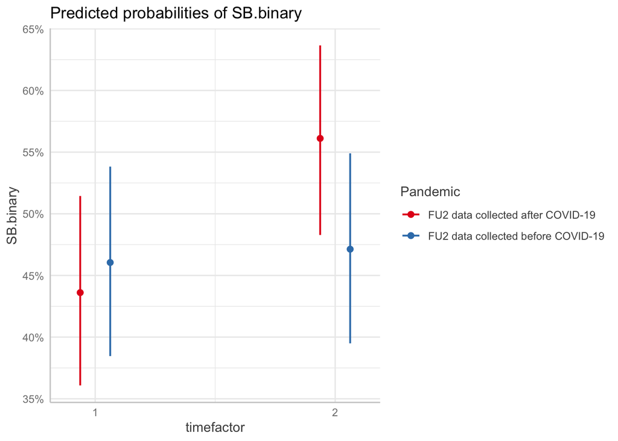

```r
ggpredict(sit1, c("timefactor", "Pandemic")) %>% plot()
```

### 8.1.5) Post-hoc analysis

Calculating between-cohort changes from FU1 to FU2

```r
#mean difference
mean.diff.1a<-((subset(sit.test,x==1 & group == "FU2 data collected after COVID-19")$predicted -
         subset(sit.test,x==2 & group == "FU2 data collected after COVID-19")$predicted))

mean.diff.1b<-((subset(sit.test,x==1 & group == "FU2 data collected before COVID-19")$predicted -
         subset(sit.test,x==2 & group == "FU2 data collected before COVID-19")$predicted))

mean.change<- mean.diff.1a - mean.diff.1b

#standard error
se.change<-(sqrt(((subset(sit.test,x==2 & group == "FU2 data collected after COVID-19")$standard.error)^2 +
         (subset(sit.test,x==2 & group == "FU2 data collected after COVID-19")$standard.error^2 +
            (subset(sit.test,x==2 & group == "FU2 data collected before COVID-19")$standard.error)^2 +
            (subset(sit.test,x==2 & group == "FU2 data collected before COVID-19")$standard.error)^2 ))/4))

#confidence interval
UL.change<-mean.change + se.change*1.96
LL.change<-mean.change - se.change*1.96

#t-score
t.change<-mean.change/se.change

#degrees of freedom
df <- length(Tracking.data_long_2$SB.binary)/2 - 2

#p-value
p.change <- pt(t.change, df)
```

Estimated between-cohort changes from FU1 to FU2

```r
mean.change #Between-cohort changes from FU1 to FU2
```

```
## [1] -0.1142478
```

```r
LL.change #LL 95% CI
```

```
## [1] -0.1915995
```

```r
UL.change #UL 95% CI
```

```
## [1] -0.03689607
```

```r
p.change #p-value
```

```
## [1] 0.001899997
```

## 8.2) Age and Sex Interaction Model

### 8.2.1) Model

```r
sit2 <- glmer(
  SB.binary ~ timefactor*Pandemic*Age_sex + SBbaseline.binary + Education + Ethnicity + IncomeLevel + BMI + CESD.10baseline + SmokingStatus +
    Relationshipstatus + Livingstatus + Anxiety + MoodDisord + Chronicconditions +
    (1|ID),
  data = Tracking.data_long_2,
  family = binomial(link = "logit")
)
summary(sit2)
```

```
## Generalized linear mixed model fit by maximum likelihood (Laplace
##   Approximation) [glmerMod]
##  Family: binomial  ( logit )
## Formula: SB.binary ~ timefactor * Pandemic * Age_sex + SBbaseline.binary +
##     Education + Ethnicity + IncomeLevel + BMI + CESD.10baseline +
##     SmokingStatus + Relationshipstatus + Livingstatus + Anxiety +
##     MoodDisord + Chronicconditions + (1 | ID)
##    Data: Tracking.data_long_2
##
##      AIC      BIC   logLik deviance df.resid
##  25572.8  25897.8 -12745.4  25490.8    20418
##
## Scaled residuals:
##     Min      1Q  Median      3Q     Max
## -2.9725 -0.6485 -0.4583  0.8000  2.0476
##
## Random effects:
##  Groups Name        Variance Std.Dev.
##  ID     (Intercept) 0.8091   0.8995
## Number of obs: 20459, groups:  ID, 10233
##
## Fixed effects:
##                                                                            Estimate
## (Intercept)                                                               -1.631680
## timefactor2                                                                0.570316
## PandemicFU2 data collected before COVID-19                                 0.065054
## Age_sexFemales 65+                                                         0.378322
## Age_sexMales 45-64                                                        -0.142570
## Age_sexMales 65+                                                           0.286948
## SBbaseline.binary1                                                         1.146583
## EducationHigh School Diploma                                              -0.015102
## EducationLess than High School Diploma                                     0.079155
## EducationSome College                                                     -0.089060
## EthnicityWhite                                                            -0.050210
## IncomeLevel>$150k                                                         -0.234851
## IncomeLevel$100-150k                                                      -0.050340
## IncomeLevel$20-50k                                                        -0.172665
## IncomeLevel$50-100k                                                       -0.259894
## BMI                                                                        0.039120
## CESD.10baseline                                                            0.011842
```

[output cut: 174 more lines]

```
## AnxietyYes
## MoodDisordYes                                                             .
## Chronicconditions                                                         ***
## timefactor2:PandemicFU2 data collected before COVID-19                    **
## timefactor2:Age_sexFemales 65+
## timefactor2:Age_sexMales 45-64
## timefactor2:Age_sexMales 65+
## PandemicFU2 data collected before COVID-19:Age_sexFemales 65+
## PandemicFU2 data collected before COVID-19:Age_sexMales 45-64
## PandemicFU2 data collected before COVID-19:Age_sexMales 65+
## timefactor2:PandemicFU2 data collected before COVID-19:Age_sexFemales 65+
## timefactor2:PandemicFU2 data collected before COVID-19:Age_sexMales 45-64
## timefactor2:PandemicFU2 data collected before COVID-19:Age_sexMales 65+   *
## ---
## Signif. codes:  0 '***' 0.001 '**' 0.01 '*' 0.05 '.' 0.1 ' ' 1
```

```
##
## Correlation matrix not shown by default, as p = 40 > 12.
## Use print(x, correlation=TRUE)  or
##     vcov(x)        if you need it
```

```
## optimizer (Nelder_Mead) convergence code: 4 (failure to converge in 10000 evaluations)
## Model failed to converge with max|grad| = 0.867843 (tol = 0.002, component 1)
## Model is nearly unidentifiable: very large eigenvalue
##  - Rescale variables?
## failure to converge in 10000 evaluations
```

```r
anova(sit2)
```

```
## Analysis of Variance Table
##                             npar  Sum Sq Mean Sq   F value
## timefactor                     1   44.44   44.44   44.4352
## Pandemic                       1    0.43    0.43    0.4286
## Age_sex                        3  164.99   55.00   54.9956
## SBbaseline.binary              1 1106.92 1106.92 1106.9174
## Education                      3   13.89    4.63    4.6315
## Ethnicity                      1    0.13    0.13    0.1307
## IncomeLevel                    4   31.97    7.99    7.9916
## BMI                            1  142.70  142.70  142.6960
## CESD.10baseline                1   23.69   23.69   23.6924
## SmokingStatus                  3   20.03    6.68    6.6761
## Relationshipstatus             4   40.33   10.08   10.0819
## Livingstatus                   3   26.45    8.82    8.8176
## Anxiety                        1    0.05    0.05    0.0499
## MoodDisord                     1    4.52    4.52    4.5239
## Chronicconditions              1   21.28   21.28   21.2763
## timefactor:Pandemic            1   56.04   56.04   56.0419
## timefactor:Age_sex             3   17.42    5.81    5.8065
## Pandemic:Age_sex               3    4.41    1.47    1.4703
## timefactor:Pandemic:Age_sex    3    5.88    1.96    1.9608
```

### 8.2.2) Predicted probabilities

```r
ggpredict(sit2, c("Pandemic","timefactor","Age_sex"))
```

```
## # Predicted probabilities of SB.binary
##
## # timefactor = 1
## #    Age_sex = Females 45-64
##
## Pandemic                           | Predicted |       95% CI
## -------------------------------------------------------------
## FU2 data collected after COVID-19  |      0.41 | [0.33, 0.49]
## FU2 data collected before COVID-19 |      0.42 | [0.34, 0.50]
##
## # timefactor = 2
## #    Age_sex = Females 45-64
##
## Pandemic                           | Predicted |       95% CI
## -------------------------------------------------------------
## FU2 data collected after COVID-19  |      0.55 | [0.46, 0.63]
## FU2 data collected before COVID-19 |      0.48 | [0.40, 0.56]
##
## # timefactor = 1
## #    Age_sex = Females 65+
##
## Pandemic                           | Predicted |       95% CI
## -------------------------------------------------------------
## FU2 data collected after COVID-19  |      0.50 | [0.41, 0.59]
## FU2 data collected before COVID-19 |      0.51 | [0.43, 0.60]
##
## # timefactor = 2
## #    Age_sex = Females 65+
##
## Pandemic                           | Predicted |       95% CI
## -------------------------------------------------------------
## FU2 data collected after COVID-19  |      0.61 | [0.52, 0.69]
## FU2 data collected before COVID-19 |      0.49 | [0.41, 0.57]
##
## # timefactor = 1
## #    Age_sex = Males 45-64
##
## Pandemic                           | Predicted |       95% CI
## -------------------------------------------------------------
## FU2 data collected after COVID-19  |      0.37 | [0.30, 0.45]
```

[output cut: 25 more lines]

```
##
## Adjusted for:
## *  SBbaseline.binary =                        0
## *          Education = College Degree or Higher
## *          Ethnicity =                    Other
## *        IncomeLevel =                    <$20k
## *                BMI =                    27.52
## *    CESD.10baseline =                     4.87
## *      SmokingStatus =             Daily Smoker
## * Relationshipstatus =                 Divorced
## *       Livingstatus = Apartment/Condo/Townhome
## *            Anxiety =                       No
## *         MoodDisord =                       No
## *  Chronicconditions =                     2.76
## *                 ID =     0 (population-level)
```

```r
sit.test2 <- as.data.frame(ggpredict(sit2, c("timefactor", "Pandemic", "Age_sex")))

sit.test2$standard.error <- (sit.test2$predicted - sit.test2$conf.low)/1.96
```

### 8.2.3) Estimated mean differences between pre- and post-pandemic cohorts by age and sex

Calculating mean differences and 95% CIs for each age/sex group

```r
######### Females 45-64 years #########

#Calculating means and standard errors for females 45-64 years
mean.diff.Females.Young.1<-(subset(sit.test2,x==1 & group == "FU2 data collected after COVID-19" & facet == "Females 45-64")$predicted -
         subset(sit.test2,x==1 & group == "FU2 data collected before COVID-19" & facet == "Females 45-64")$predicted)

se.Females.Young.1<-(sqrt(((subset(sit.test2,x==1 & group == "FU2 data collected after COVID-19" & facet == "Females 45-64")$standard.error)^2 +
     (subset(sit.test2,x==1 & group == "FU2 data collected before COVID-19" & facet == "Females 45-64")$standard.error^2))/2))

UL.Females.Young.1<-mean.diff.Females.Young.1 + se.Females.Young.1*1.96
LL.Females.Young.1<-mean.diff.Females.Young.1 - se.Females.Young.1*1.96

mean.diff.Females.Young.2<-(subset(sit.test2,x==2 & group == "FU2 data collected after COVID-19" & facet == "Females 45-64")$predicted -
         subset(sit.test2,x==2 & group == "FU2 data collected before COVID-19" & facet == "Females 45-64")$predicted)

se.Females.Young.2<-(sqrt(((subset(sit.test2,x==2 & group == "FU2 data collected after COVID-19" & facet == "Females 45-64")$standard.error)^2 +
     (subset(sit.test2,x==2 & group == "FU2 data collected before COVID-19" & facet == "Females 45-64")$standard.error^2))/2))

UL.Females.Young.2<-mean.diff.Females.Young.2 + se.Females.Young.2*1.96
LL.Females.Young.2<-mean.diff.Females.Young.2 - se.Females.Young.2*1.96

#z-scores for females 45-64 years
z.Females.Young.1 <- (subset(sit.test2,x==1 & group == "FU2 data collected after COVID-19" & facet == "Females 45-64")$predicted -
         subset(sit.test2,x==1 & group == "FU2 data collected before COVID-19" & facet == "Females 45-64")$predicted) / (sqrt(((subset(sit.test2,x==1 & group == "FU2 data collected after COVID-19" & facet == "Females 45-64")$standard.error)^2 +
     (subset(sit.test2,x==1 & group == "FU2 data collected before COVID-19" & facet == "Females 45-64")$standard.error^2))/2))

z.Females.Young.2 <- (subset(sit.test2,x==2 & group == "FU2 data collected after COVID-19" & facet == "Females 45-64")$predicted -
         subset(sit.test2,x==2 & group == "FU2 data collected before COVID-19" & facet == "Females 45-64")$predicted) / (sqrt(((subset(sit.test2,x==2 & group == "FU2 data collected after COVID-19" & facet == "Females 45-64")$standard.error)^2 +
         (subset(sit.test2,x==2 & group == "FU2 data collected before COVID-19" & facet == "Females 45-64")$standard.error^2))/2))

#p-values for females 45-64 years
p.Females.Young.1<-2*pnorm(z.Females.Young.1, mean = 0, sd = 1, lower.tail = TRUE)
p.Females.Young.2<-2*pnorm(z.Females.Young.2, mean = 0, sd = 1, lower.tail = FALSE)


########### Females 65+ years ###########

#Calculating means and standard errors for females  65+ years
mean.diff.Females.Old.1<-(subset(sit.test2,x==1 & group == "FU2 data collected after COVID-19" & facet == "Females 65+")$predicted -
         subset(sit.test2,x==1 & group == "FU2 data collected before COVID-19" & facet == "Females 65+")$predicted)

se.Females.Old.1<-(sqrt(((subset(sit.test2,x==1 & group == "FU2 data collected after COVID-19" & facet == "Females 65+")$standard.error)^2 +
     (subset(sit.test2,x==1 & group == "FU2 data collected before COVID-19" & facet == "Females 65+")$standard.error^2))/2))

UL.Females.Old.1<-mean.diff.Females.Old.1 + se.Females.Old.1*1.96
LL.Females.Old.1<-mean.diff.Females.Old.1 - se.Females.Old.1*1.96

mean.diff.Females.Old.2<-(subset(sit.test2,x==2 & group == "FU2 data collected after COVID-19" & facet == "Females 65+")$predicted -
         subset(sit.test2,x==2 & group == "FU2 data collected before COVID-19" & facet == "Females 65+")$predicted)

se.Females.Old.2<-(sqrt(((subset(sit.test2,x==2 & group == "FU2 data collected after COVID-19" & facet == "Females 65+")$standard.error)^2 +
     (subset(sit.test2,x==2 & group == "FU2 data collected before COVID-19" & facet == "Females 65+")$standard.error^2))/2))

UL.Females.Old.2<-mean.diff.Females.Old.2 + se.Females.Old.2*1.96
LL.Females.Old.2<-mean.diff.Females.Old.2 - se.Females.Old.2*1.96

#z-scores for females 65+ years
z.Females.Old.1 <- (subset(sit.test2,x==1 & group == "FU2 data collected after COVID-19" & facet == "Females 65+")$predicted -
         subset(sit.test2,x==1 & group == "FU2 data collected before COVID-19" & facet == "Females 65+")$predicted) / (sqrt(((subset(sit.test2,x==1 & group == "FU2 data collected after COVID-19" & facet == "Females 65+")$standard.error)^2 +
     (subset(sit.test2,x==1 & group == "FU2 data collected before COVID-19" & facet == "Females 65+")$standard.error^2))/2))

z.Females.Old.2 <- (subset(sit.test2,x==2 & group == "FU2 data collected after COVID-19" & facet == "Females 65+")$predicted -
         subset(sit.test2,x==2 & group == "FU2 data collected before COVID-19" & facet == "Females 65+")$predicted) / (sqrt(((subset(sit.test2,x==2 & group == "FU2 data collected after COVID-19" & facet == "Females 65+")$standard.error)^2 +
         (subset(sit.test2,x==2 & group == "FU2 data collected before COVID-19" & facet == "Females 65+")$standard.error^2))/2))

#p-values for females 65+ years
p.Females.Old.1<-2*pnorm(z.Females.Old.1, mean = 0, sd = 1, lower.tail = TRUE)
p.Females.Old.2<-2*pnorm(z.Females.Old.2, mean = 0, sd = 1, lower.tail = FALSE)



########## Males 45-64 years ###########

#Calculating means and standard errors for males 45-64 years
mean.diff.Males.Young.1<-(subset(sit.test2,x==1 & group == "FU2 data collected after COVID-19" & facet == "Males 45-64")$predicted -
         subset(sit.test2,x==1 & group == "FU2 data collected before COVID-19" & facet == "Males 45-64")$predicted)

se.Males.Young.1<-(sqrt(((subset(sit.test2,x==1 & group == "FU2 data collected after COVID-19" & facet == "Males 45-64")$standard.error)^2 +
     (subset(sit.test2,x==1 & group == "FU2 data collected before COVID-19" & facet == "Males 45-64")$standard.error^2))/2))

UL.Males.Young.1<-mean.diff.Males.Young.1 + se.Males.Young.1*1.96
LL.Males.Young.1<-mean.diff.Males.Young.1 - se.Males.Young.1*1.96

mean.diff.Males.Young.2<-(subset(sit.test2,x==2 & group == "FU2 data collected after COVID-19" & facet == "Males 45-64")$predicted -
         subset(sit.test2,x==2 & group == "FU2 data collected before COVID-19" & facet == "Males 45-64")$predicted)

se.Males.Young.2<-(sqrt(((subset(sit.test2,x==2 & group == "FU2 data collected after COVID-19" & facet == "Males 45-64")$standard.error)^2 +
     (subset(sit.test2,x==2 & group == "FU2 data collected before COVID-19" & facet == "Males 45-64")$standard.error^2))/2))

UL.Males.Young.2<-mean.diff.Males.Young.2 + se.Males.Young.2*1.96
LL.Males.Young.2<-mean.diff.Males.Young.2 - se.Males.Young.2*1.96

#z-scores for males 45-64 years
z.Males.Young.1 <- (subset(sit.test2,x==1 & group == "FU2 data collected after COVID-19" & facet == "Males 45-64")$predicted -
         subset(sit.test2,x==1 & group == "FU2 data collected before COVID-19" & facet == "Males 45-64")$predicted) / (sqrt(((subset(sit.test2,x==1 & group == "FU2 data collected after COVID-19" & facet == "Males 45-64")$standard.error)^2 +
     (subset(sit.test2,x==1 & group == "FU2 data collected before COVID-19" & facet == "Males 45-64")$standard.error^2))/2))

z.Males.Young.2 <- (subset(sit.test2,x==2 & group == "FU2 data collected after COVID-19" & facet == "Males 45-64")$predicted -
         subset(sit.test2,x==2 & group == "FU2 data collected before COVID-19" & facet == "Males 45-64")$predicted) / (sqrt(((subset(sit.test2,x==2 & group == "FU2 data collected after COVID-19" & facet == "Males 45-64")$standard.error)^2 +
         (subset(sit.test2,x==2 & group == "FU2 data collected before COVID-19" & facet == "Males 45-64")$standard.error^2))/2))

#p-values for males 45-64 years
p.Males.Young.1<-2*pnorm(z.Males.Young.1, mean = 0, sd = 1, lower.tail = TRUE)
p.Males.Young.2<-2*pnorm(z.Males.Young.2, mean = 0, sd = 1, lower.tail = FALSE)


########## Males 65+ years ###########

#Calculating means and standard errors for males 65+ years
mean.diff.Males.Old.1<-(subset(sit.test2,x==1 & group == "FU2 data collected after COVID-19" & facet == "Males 65+")$predicted -
         subset(sit.test2,x==1 & group == "FU2 data collected before COVID-19" & facet == "Males 65+")$predicted)

se.Males.Old.1<-(sqrt(((subset(sit.test2,x==1 & group == "FU2 data collected after COVID-19" & facet == "Males 65+")$standard.error)^2 +
     (subset(sit.test2,x==1 & group == "FU2 data collected before COVID-19" & facet == "Males 65+")$standard.error^2))/2))

UL.Males.Old.1<-mean.diff.Males.Old.1 + se.Males.Old.1*1.96
LL.Males.Old.1<-mean.diff.Males.Old.1 - se.Males.Old.1*1.96

mean.diff.Males.Old.2<-(subset(sit.test2,x==2 & group == "FU2 data collected after COVID-19" & facet == "Males 65+")$predicted -
         subset(sit.test2,x==2 & group == "FU2 data collected before COVID-19" & facet == "Males 65+")$predicted)

se.Males.Old.2<-(sqrt(((subset(sit.test2,x==2 & group == "FU2 data collected after COVID-19" & facet == "Males 65+")$standard.error)^2 +
     (subset(sit.test2,x==2 & group == "FU2 data collected before COVID-19" & facet == "Males 65+")$standard.error^2))/2))

UL.Males.Old.2<-mean.diff.Males.Old.2 + se.Males.Old.2*1.96
LL.Males.Old.2<-mean.diff.Males.Old.2 - se.Males.Old.2*1.96

#z-scores for males 65+ years
z.Males.Old.1 <- (subset(sit.test2,x==1 & group == "FU2 data collected after COVID-19" & facet == "Males 65+")$predicted -
         subset(sit.test2,x==1 & group == "FU2 data collected before COVID-19" & facet == "Males 65+")$predicted) / (sqrt(((subset(sit.test2,x==1 & group == "FU2 data collected after COVID-19" & facet == "Males 65+")$standard.error)^2 +
     (subset(sit.test2,x==1 & group == "FU2 data collected before COVID-19" & facet == "Males 65+")$standard.error^2))/2))

z.Males.Old.2 <- (subset(sit.test2,x==2 & group == "FU2 data collected after COVID-19" & facet == "Males 65+")$predicted -
         subset(sit.test2,x==2 & group == "FU2 data collected before COVID-19" & facet == "Males 65+")$predicted) / (sqrt(((subset(sit.test2,x==2 & group == "FU2 data collected after COVID-19" & facet == "Males 65+")$standard.error)^2 +
         (subset(sit.test2,x==2 & group == "FU2 data collected before COVID-19" & facet == "Males 65+")$standard.error^2))/2))

#p-values for males 65+ years
p.Males.Old.1<-2*pnorm(z.Males.Old.1, mean = 0, sd = 1, lower.tail = TRUE)
p.Males.Old.2<-2*pnorm(z.Males.Old.2, mean = 0, sd = 1, lower.tail = FALSE)
```

Mean differences and 95% CIs for females 45-64 years at FU1

```r
mean.diff.Females.Young.1 #Estimated mean difference
```

```
## [1] -0.01577137
```

```r
LL.Females.Young.1 #LL CI
```

```
## [1] -0.09273829
```

```r
UL.Females.Young.1 #UL CI
```

```
## [1] 0.06119554
```

```r
z.Females.Young.1 #z-score
```

```
## [1] -0.4016258
```

```r
p.Females.Young.1 #p-value
```

```
## [1] 0.6879595
```

Mean differences and 95% CIs for females 45-64 years at FU2

```r
mean.diff.Females.Young.2 #Estimated mean difference
```

```
## [1] 0.07062588
```

```r
LL.Females.Young.2 #LL CI
```

```
## [1] -0.01067672
```

```r
UL.Females.Young.2 #UL CI
```

```
## [1] 0.1519285
```

```r
z.Females.Young.2 #z-score
```

```
## [1] 1.702611
```

```r
p.Females.Young.2 #p-value
```

```
## [1] 0.08864084
```

Mean differences and 95% CIs for females 65+ years at FU1

```r
mean.diff.Females.Old.1 #Estimated mean difference
```

```
## [1] -0.01509938
```

```r
LL.Females.Old.1 #LL CI
```

```
## [1] -0.1012975
```

```r
UL.Females.Old.1 #UL CI
```

```
## [1] 0.07109877
```

```r
z.Females.Old.1 #z-score
```

```
## [1] -0.3433344
```

```r
p.Females.Old.1 #p-value
```

```
## [1] 0.7313469
```

Mean differences and 95% CIs for females 65+ years at FU2 (significant)

```r
mean.diff.Females.Old.2 #Estimated mean difference
```

```
## [1] 0.1198825
```

```r
LL.Females.Old.2 #LL CI
```

```
## [1] 0.0343009
```

```r
UL.Females.Old.2 #UL CI
```

```
## [1] 0.205464
```

```r
z.Females.Old.2 #z-score
```

```
## [1] 2.745564
```

```r
p.Females.Old.2 #p-value
```

```
## [1] 0.006040705
```

Mean differences and 95% CIs for males 45-64 years at FU1

```r
mean.diff.Males.Young.1 #Estimated mean difference
```

```
## [1] -0.03619372
```

```r
LL.Males.Young.1 #LL CI
```

```
## [1] -0.1123435
```

```r
UL.Males.Young.1 #UL CI
```

```
## [1] 0.0399561
```

```r
z.Males.Young.1 #z-score
```

```
## [1] -0.9315806
```

```r
p.Males.Young.1 #p-value
```

```
## [1] 0.3515533
```

Mean differences and 95% CIs for males 45-64 years at FU2

```r
mean.diff.Males.Young.2 #Estimated mean difference
```

```
## [1] 0.04974474
```

```r
LL.Males.Young.2 #LL CI
```

```
## [1] -0.03160921
```

```r
UL.Males.Young.2 #UL CI
```

```
## [1] 0.1310987
```

```r
z.Males.Young.2 #z-score
```

```
## [1] 1.198463
```

```r
p.Males.Young.2 #p-value
```

```
## [1] 0.2307368
```

Mean differences and 95% CIs for males 65+ years at FU1

```r
mean.diff.Males.Old.1 #Estimated mean difference
```

```
## [1] -0.04110959
```

```r
LL.Males.Old.1 #LL CI
```

```
## [1] -0.1281436
```

```r
UL.Males.Old.1 #UL CI
```

```
## [1] 0.04592443
```

```r
z.Males.Old.1 #z-score
```

```
## [1] -0.9257851
```

```r
p.Males.Old.1 #p-value
```

```
## [1] 0.3545577
```

Mean differences and 95% CIs for males 65+ years at FU2

```r
mean.diff.Males.Old.2 #Estimated mean difference
```

```
## [1] 0.1424974
```

```r
LL.Males.Old.2 #LL CI
```

```
## [1] 0.05639773
```

```r
UL.Males.Old.2 #UL CI
```

```
## [1] 0.228597
```

```r
z.Males.Old.2 #z-score
```

```
## [1] 3.243856
```

```r
p.Males.Old.2 #p-value
```

```
## [1] 0.001179233
```

### 8.2.4) Graph of predicted probabilities

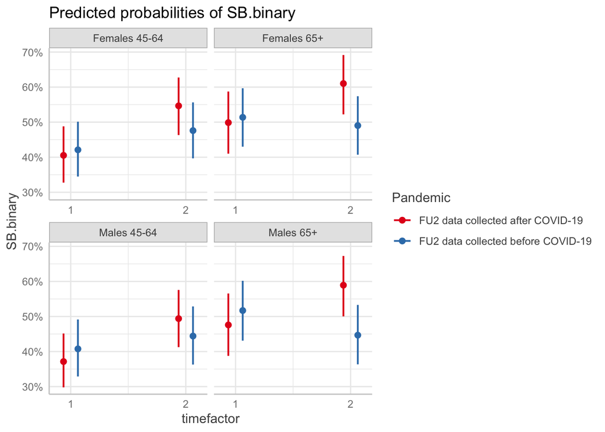

```r
ggpredict(sit2, c("timefactor","Pandemic","Age_sex")) %>% plot()
```

### 8.2.5) Post-hoc comparisons

There were significant differences between Pre- and Post-pandemic cohorts at FU2 for females 65+ and for males 65+ . We now examine whether there significant changes from FU1 to FU2 in the probability of sitting 4+ hours/day between Pre- and Post-pandemic cohorts for females 65+ and males 65+.

Calculating between-cohort changes from FU1 to FU2 for females 65+ and males 65+

```r
####### Females 65+ ###########

#mean difference
mean.diff.Females.Old.1a<-((subset(sit.test2,x==1 & group == "FU2 data collected after COVID-19" & facet == "Females 65+")$predicted -
         subset(sit.test2,x==2 & group == "FU2 data collected after COVID-19" & facet == "Females 65+")$predicted))

mean.diff.Females.Old.1b<-((subset(sit.test2,x==1 & group == "FU2 data collected before COVID-19" & facet == "Females 65+")$predicted -
         subset(sit.test2,x==2 & group == "FU2 data collected before COVID-19" & facet == "Females 65+")$predicted))

mean.Females.Old.change<- mean.diff.Females.Old.1a - mean.diff.Females.Old.1b

#standard error
se.change.Females.Old <-(sqrt(((subset(sit.test2,x==2 & group == "FU2 data collected after COVID-19" & facet == "Females 65+")$standard.error)^2 +
         (subset(sit.test2,x==2 & group == "FU2 data collected after COVID-19" & facet == "Females 65+")$standard.error^2 +
            (subset(sit.test2,x==2 & group == "FU2 data collected before COVID-19" & facet == "Females 65+")$standard.error)^2 +
            (subset(sit.test2,x==2 & group == "FU2 data collected before COVID-19" & facet == "Females 65+")$standard.error)^2 ))/4))

#confidence interval
UL.Females.Old.change<-mean.Females.Old.change + se.change.Females.Old*1.96
LL.Females.Old.change<-mean.Females.Old.change - se.change.Females.Old*1.96

#t-score
t.Females.Old.change<-mean.Females.Old.change/se.change.Females.Old

#degrees of freedom
df.Females.Old <- nrow(Tracking.data_long_2[Tracking.data_long_2$Age_sex == "Females 65+" & !is.na(Tracking.data_long_2$SB.binary), ])/2 - 2


#p-value
p.change.Females.Old <- pt(t.Females.Old.change, df.Females.Old)

####### Males 65+ ###########

#mean difference
mean.diff.Males.Old.1a<-((subset(sit.test2,x==1 & group == "FU2 data collected after COVID-19" & facet == "Males 65+")$predicted -
         subset(sit.test2,x==2 & group == "FU2 data collected after COVID-19" & facet == "Males 65+")$predicted))

mean.diff.Males.Old.1b<-((subset(sit.test2,x==1 & group == "FU2 data collected before COVID-19" & facet == "Males 65+")$predicted -
         subset(sit.test2,x==2 & group == "FU2 data collected before COVID-19" & facet == "Males 65+")$predicted))

mean.Males.Old.change<- mean.diff.Males.Old.1a - mean.diff.Males.Old.1b

#standard error
se.change.Males.Old <-(sqrt(((subset(sit.test2,x==2 & group == "FU2 data collected after COVID-19" & facet == "Males 65+")$standard.error)^2 +
         (subset(sit.test2,x==2 & group == "FU2 data collected after COVID-19" & facet == "Males 65+")$standard.error^2 +
            (subset(sit.test2,x==2 & group == "FU2 data collected before COVID-19" & facet == "Males 65+")$standard.error)^2 +
            (subset(sit.test2,x==2 & group == "FU2 data collected before COVID-19" & facet == "Males 65+")$standard.error)^2 ))/4))

#confidence interval
UL.Males.Old.change<-mean.Males.Old.change + se.change.Males.Old*1.96
LL.Males.Old.change<-mean.Males.Old.change - se.change.Males.Old*1.96

#t-score
t.Males.Old.change<-mean.Males.Old.change/se.change.Males.Old

#degrees of freedom
df.Males.Old <- nrow(Tracking.data_long_2[Tracking.data_long_2$Age_sex == "Males 65+" & !is.na(Tracking.data_long_2$SB.binary), ])/2 - 2


#p-value
p.change.Males.Old <- pt(t.Males.Old.change, df.Males.Old)
```

Estimated between-cohort changes from FU1 to FU2 for females 65+

```r
mean.Females.Old.change #Between-cohort changes from FU1 to FU2
```

```
## [1] -0.1349818
```

```r
LL.Females.Old.change #LL 95% CI
```

```
## [1] -0.2205634
```

```r
UL.Females.Old.change #UL 95% CI
```

```
## [1] -0.04940028
```

```r
p.change.Females.Old #p-value
```

```
## [1] 0.001009007
```

Estimated between-cohort changes from FU1 to FU2 for males 65+

```r
mean.Males.Old.change #Between-cohort changes from FU1 to FU2
```

```
## [1] -0.183607
```

```r
LL.Males.Old.change #LL 95% CI
```

```
## [1] -0.2697066
```

```r
UL.Males.Old.change #UL 95% CI
```

```
## [1] -0.09750731
```

```r
p.change.Males.Old #p-value
```

```
## [1] 1.522222e-05
```

Effect size females 65+

```r
n_females_65_highSB<-nrow(subset(Tracking.Adjusted_Final, Age_sex == "Females 65+" & Pandemic == "FU2 data collected after COVID-19" & SB.binary_0==1))
n_females_65_lowSB<-nrow(subset(Tracking.Adjusted_Final, Age_sex == "Females 65+" & Pandemic == "FU2 data collected after COVID-19" & SB.binary_0==0))
es.SB.females<-(t.Females.Old.change)*(sqrt((n_females_65_highSB + n_females_65_lowSB)/(n_females_65_lowSB*n_females_65_highSB)))
print(es.SB.females)
```

```
## [1] -0.2169645
```

Effect size males 65+

```r
n_males_65_highSB<-nrow(subset(Tracking.Adjusted_Final, Age_sex == "Males 65+" & Pandemic == "FU2 data collected after COVID-19" & SB.binary_0==1))
n_males_65_lowSB<-nrow(subset(Tracking.Adjusted_Final, Age_sex == "Males 65+" & Pandemic == "FU2 data collected after COVID-19" & SB.binary_0==0))
es.SB.males<-(t.Males.Old.change)*(sqrt((n_males_65_highSB + n_males_65_lowSB)/(n_males_65_lowSB*n_males_65_highSB)))
print(es.SB.males)
```

```
## [1] -0.2971414
```

# 9) Sleep Results

## 9.1) Main effects model adjusted for baseline

### 9.1.1) Model

```r
sleep1 <- glmer(
  RSTLS_Sleep ~ timefactor*Pandemic + Age + Sex + RSTLS_Sleepbaseline + Education + Ethnicity + IncomeLevel + BMI + CESD.10baseline + SmokingStatus +
    Relationshipstatus + Livingstatus + Anxiety + MoodDisord + Chronicconditions +
    (1|ID),
  data = Tracking.data_long_2,
  family = binomial(link = "logit")
)
summary(sleep1)
```

```
## Generalized linear mixed model fit by maximum likelihood (Laplace
##   Approximation) [glmerMod]
##  Family: binomial  ( logit )
## Formula:
## RSTLS_Sleep ~ timefactor * Pandemic + Age + Sex + RSTLS_Sleepbaseline +
##     Education + Ethnicity + IncomeLevel + BMI + CESD.10baseline +
##     SmokingStatus + Relationshipstatus + Livingstatus + Anxiety +
##     MoodDisord + Chronicconditions + (1 | ID)
##    Data: Tracking.data_long_2
##
##      AIC      BIC   logLik deviance df.resid
##  24480.7  24726.9 -12209.3  24418.7    20731
##
## Scaled residuals:
##     Min      1Q  Median      3Q     Max
## -2.1468 -0.5765 -0.4261  0.8298  2.1750
##
## Random effects:
##  Groups Name        Variance Std.Dev.
##  ID     (Intercept) 0.8005   0.8947
## Number of obs: 20762, groups:  ID, 10407
##
## Fixed effects:
##                                                         Estimate Std. Error
## (Intercept)                                            -1.101766   0.240638
## timefactor2                                            -0.184424   0.049089
## PandemicFU2 data collected before COVID-19             -0.007853   0.050754
## Age                                                    -0.011876   0.002320
## SexM                                                   -0.209542   0.042217
## RSTLS_Sleepbaseline                                     0.913048   0.044699
## EducationHigh School Diploma                            0.139834   0.058837
## EducationLess than High School Diploma                  0.224461   0.080637
## EducationSome College                                   0.148781   0.073649
## EthnicityWhite                                          0.159890   0.119647
## IncomeLevel>$150k                                      -0.062121   0.113232
## IncomeLevel$100-150k                                    0.013985   0.088940
## IncomeLevel$20-50k                                     -0.044483   0.057356
## IncomeLevel$50-100k                                     0.009227   0.062277
## BMI                                                     0.001927   0.003810
## CESD.10baseline                                         0.063722   0.005144
```

[output cut: 32 more lines]

```
## SmokingStatusNever Smoked                               -0.802 0.422357
## SmokingStatusOccasional Smoker                          -0.650 0.515376
## RelationshipstatusMarried                               -0.866 0.386476
## RelationshipstatusSeparated                             -2.772 0.005568 **
## RelationshipstatusSingle                                -2.280 0.022592 *
## RelationshipstatusWidowed                               -1.583 0.113518
## LivingstatusAssisted Living                              0.762 0.445933
## LivingstatusHouse                                        2.235 0.025411 *
## LivingstatusOther                                       -0.255 0.798573
## AnxietyYes                                              -1.792 0.073201 .
## MoodDisordYes                                           -0.548 0.583389
## Chronicconditions                                        9.099  < 2e-16 ***
## timefactor2:PandemicFU2 data collected before COVID-19  -0.166 0.868079
## ---
## Signif. codes:  0 '***' 0.001 '**' 0.01 '*' 0.05 '.' 0.1 ' ' 1
```

```
##
## Correlation matrix not shown by default, as p = 30 > 12.
## Use print(x, correlation=TRUE)  or
##     vcov(x)        if you need it
```

```
## optimizer (Nelder_Mead) convergence code: 4 (failure to converge in 10000 evaluations)
## Model failed to converge with max|grad| = 1.36972 (tol = 0.002, component 1)
## Model is nearly unidentifiable: very large eigenvalue
##  - Rescale variables?
## failure to converge in 10000 evaluations
```

```r
anova(sleep1)
```

```
## Analysis of Variance Table
##                     npar Sum Sq Mean Sq  F value
## timefactor             1  25.91   25.91  25.9052
## Pandemic               1   0.20    0.20   0.1998
## Age                    1  11.97   11.97  11.9731
## Sex                    1  70.89   70.89  70.8865
## RSTLS_Sleepbaseline    1 960.16  960.16 960.1553
## Education              3  23.50    7.83   7.8345
## Ethnicity              1   1.25    1.25   1.2520
## IncomeLevel            4   7.11    1.78   1.7772
## BMI                    1  10.21   10.21  10.2080
## CESD.10baseline        1 200.15  200.15 200.1478
## SmokingStatus          3   9.69    3.23   3.2316
## Relationshipstatus     4  14.95    3.74   3.7387
## Livingstatus           3   5.08    1.69   1.6926
## Anxiety                1   1.30    1.30   1.2971
## MoodDisord             1   0.08    0.08   0.0831
## Chronicconditions      1  89.46   89.46  89.4606
## timefactor:Pandemic    1   0.03    0.03   0.0296
```

### 9.1.2) Predicted probabilities

```r
ggpredict(sleep1, c("timefactor", "Pandemic"))
```

```
## # Predicted probabilities of RSTLS_Sleep
##
## # Pandemic = FU2 data collected after COVID-19
##
## timefactor | Predicted |       95% CI
## -------------------------------------
## 1          |      0.29 | [0.22, 0.36]
## 2          |      0.25 | [0.19, 0.32]
##
## # Pandemic = FU2 data collected before COVID-19
##
## timefactor | Predicted |       95% CI
## -------------------------------------
## 1          |      0.28 | [0.22, 0.35]
## 2          |      0.25 | [0.19, 0.31]
##
## Adjusted for:
## *                 Age =                    60.00
## *                 Sex =                        F
## * RSTLS_Sleepbaseline =                     0.33
## *           Education = College Degree or Higher
## *           Ethnicity =                    Other
## *         IncomeLevel =                    <$20k
## *                 BMI =                    27.53
## *     CESD.10baseline =                     4.88
## *       SmokingStatus =             Daily Smoker
## *  Relationshipstatus =                 Divorced
## *        Livingstatus = Apartment/Condo/Townhome
## *             Anxiety =                       No
## *          MoodDisord =                       No
## *   Chronicconditions =                     2.76
## *                  ID =     0 (population-level)
```

### 9.1.3) Estimated Mean Differences Between Pre- and Post-pandemic Cohorts at FU1 and FU2

Calculating estimated mean differences between cohorts

```r
#Create data frame
sleep.test <- as.data.frame(ggpredict(sleep1, c("timefactor", "Pandemic")))

#Determine standard errors
sleep.test$standard.error <- (sleep.test$predicted - sleep.test$conf.low)/1.96

#Calculating estimated mean differences between cohorts at FU1
mean.diff.1a<-(subset(sleep.test,x==1 & group == "FU2 data collected after COVID-19")$predicted -
         subset(sleep.test,x==1 & group == "FU2 data collected before COVID-19")$predicted)

se.1a<-(sqrt(((subset(sleep.test,x==1 & group == "FU2 data collected after COVID-19")$standard.error)^2 +
         (subset(sleep.test,x==1 & group == "FU2 data collected before COVID-19")$standard.error^2))/2))

UL.1a<-mean.diff.1a + se.1a*1.96
LL.1a<-mean.diff.1a - se.1a*1.96


#Calculating estimated mean differences between cohorts at FU2
mean.diff.2a<-(subset(sleep.test,x==2 & group == "FU2 data collected after COVID-19")$predicted -
         subset(sleep.test,x==2 & group == "FU2 data collected before COVID-19")$predicted)

se.2a<-(sqrt(((subset(sleep.test,x==2 & group == "FU2 data collected after COVID-19")$standard.error)^2 +
         (subset(sleep.test,x==2 & group == "FU2 data collected before COVID-19")$standard.error^2))/2))

UL.2a<-mean.diff.2a + se.2a*1.96
LL.2a<-mean.diff.2a - se.2a*1.96


#Calculating z-scores for differences
z.1a<- (subset(sleep.test,x==1 & group == "FU2 data collected after COVID-19")$predicted -
         subset(sleep.test,x==1 & group == "FU2 data collected before COVID-19")$predicted) / (sqrt(((subset(sleep.test,x==1 & group == "FU2 data collected after COVID-19")$standard.error)^2 +
     (subset(sleep.test,x==1 & group == "FU2 data collected before COVID-19")$standard.error^2))/2))

z.2a<- (subset(sleep.test,x==2 & group == "FU2 data collected after COVID-19")$predicted -
         subset(sleep.test,x==2 & group == "FU2 data collected before COVID-19")$predicted) / (sqrt(((subset(sleep.test,x==2 & group == "FU2 data collected after COVID-19")$standard.error)^2 +
         (subset(sleep.test,x==2 & group == "FU2 data collected before COVID-19")$standard.error^2))/2))


#p-values for z-scores
p.1a<-2*pnorm(z.1a, mean = 0, sd = 1, lower.tail = FALSE)
p.2a<-2*pnorm(z.2a, mean = 0, sd = 1, lower.tail = FALSE)
```

Estimated mean differences between cohorts at FU1

```r
mean.diff.1a #mean difference
```

```
## [1] 0.001602157
```

```r
LL.1a #Lower 95% CI
```

```
## [1] -0.05942352
```

```r
UL.1a #Upper 95% CI
```

```
## [1] 0.06262783
```

```r
z.1a # z-score
```

```
## [1] 0.05145749
```

```r
p.1a #p-value
```

```
## [1] 0.958961
```

Estimated mean differences between cohorts at FU2

```r
mean.diff.2a #mean difference
```

```
## [1] 0.003534739
```

```r
LL.2a #Lower 95% CI
```

```
## [1] -0.0517981
```

```r
UL.2a #Upper 95% CI
```

```
## [1] 0.05886758
```

```r
z.2a # z-score
```

```
## [1] 0.1252075
```

```r
p.2a #p-value
```

```
## [1] 0.9003593
```

### 9.1.4) Graph of predicted probabilities

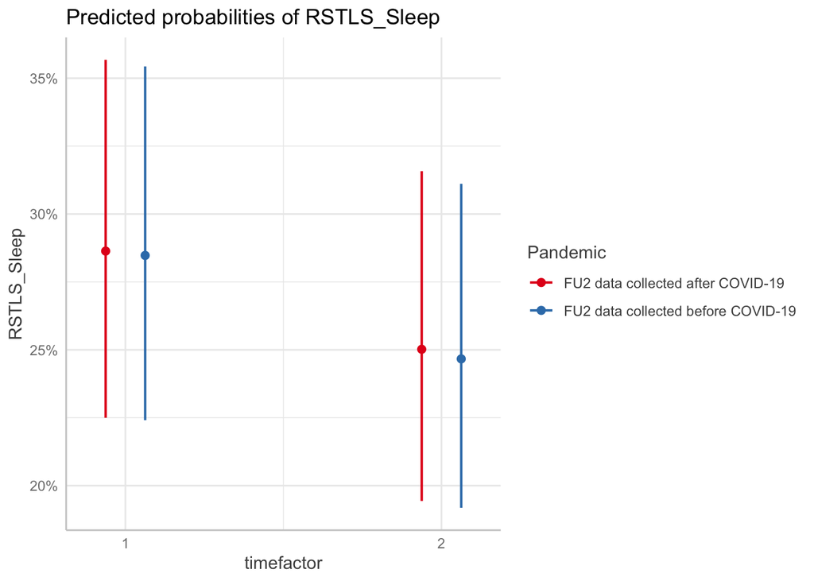

```r
ggpredict(sleep1, c("timefactor", "Pandemic")) %>% plot()
```

### 9.1.5) Post-hoc analysis

There are no significant differences between cohorts, and thus no post-hoc testing.

## 9.2) Age and Sex Interaction Model

### 9.2.1) Model

```r
sleep2 <- glmer(
  RSTLS_Sleep ~ timefactor*Pandemic*Age_sex + RSTLS_Sleepbaseline + Education + Ethnicity + IncomeLevel + BMI + CESD.10baseline + SmokingStatus +
    Relationshipstatus + Livingstatus + Anxiety + MoodDisord + Chronicconditions +
    (1|ID),
  data = Tracking.data_long_2,
  family = binomial(link = "logit")
)
summary(sleep2)
```

```
## Generalized linear mixed model fit by maximum likelihood (Laplace
##   Approximation) [glmerMod]
##  Family: binomial  ( logit )
## Formula: RSTLS_Sleep ~ timefactor * Pandemic * Age_sex + RSTLS_Sleepbaseline +
##     Education + Ethnicity + IncomeLevel + BMI + CESD.10baseline +
##     SmokingStatus + Relationshipstatus + Livingstatus + Anxiety +
##     MoodDisord + Chronicconditions + (1 | ID)
##    Data: Tracking.data_long_2
##
##      AIC      BIC   logLik deviance df.resid
##  24481.7  24807.3 -12199.9  24399.7    20721
##
## Scaled residuals:
##     Min      1Q  Median      3Q     Max
## -2.2534 -0.5763 -0.4240  0.8275  2.3373
##
## Random effects:
##  Groups Name        Variance Std.Dev.
##  ID     (Intercept) 0.8078   0.8988
## Number of obs: 20762, groups:  ID, 10407
##
## Fixed effects:
##                                                                            Estimate
## (Intercept)                                                               -1.671773
## timefactor2                                                               -0.281688
## PandemicFU2 data collected before COVID-19                                -0.155181
## Age_sexFemales 65+                                                        -0.226663
## Age_sexMales 45-64                                                        -0.510486
## Age_sexMales 65+                                                          -0.477572
## RSTLS_Sleepbaseline                                                        0.911139
## EducationHigh School Diploma                                               0.135689
## EducationLess than High School Diploma                                     0.204534
## EducationSome College                                                      0.132670
## EthnicityWhite                                                             0.131442
## IncomeLevel>$150k                                                          0.014420
## IncomeLevel$100-150k                                                       0.077726
## IncomeLevel$20-50k                                                        -0.022403
## IncomeLevel$50-100k                                                        0.037373
## BMI                                                                        0.003336
## CESD.10baseline                                                            0.064369
```

[output cut: 174 more lines]

```
## AnxietyYes
## MoodDisordYes
## Chronicconditions                                                         ***
## timefactor2:PandemicFU2 data collected before COVID-19
## timefactor2:Age_sexFemales 65+
## timefactor2:Age_sexMales 45-64                                            *
## timefactor2:Age_sexMales 65+
## PandemicFU2 data collected before COVID-19:Age_sexFemales 65+
## PandemicFU2 data collected before COVID-19:Age_sexMales 45-64             **
## PandemicFU2 data collected before COVID-19:Age_sexMales 65+
## timefactor2:PandemicFU2 data collected before COVID-19:Age_sexFemales 65+
## timefactor2:PandemicFU2 data collected before COVID-19:Age_sexMales 45-64 *
## timefactor2:PandemicFU2 data collected before COVID-19:Age_sexMales 65+
## ---
## Signif. codes:  0 '***' 0.001 '**' 0.01 '*' 0.05 '.' 0.1 ' ' 1
```

```
##
## Correlation matrix not shown by default, as p = 40 > 12.
## Use print(x, correlation=TRUE)  or
##     vcov(x)        if you need it
```

```
## optimizer (Nelder_Mead) convergence code: 4 (failure to converge in 10000 evaluations)
## Model failed to converge with max|grad| = 3.59238 (tol = 0.002, component 1)
## Model is nearly unidentifiable: very large eigenvalue
##  - Rescale variables?
## failure to converge in 10000 evaluations
```

```r
anova(sleep2)
```

```
## Analysis of Variance Table
##                             npar Sum Sq Mean Sq  F value
## timefactor                     1  26.02   26.02  26.0210
## Pandemic                       1   0.22    0.22   0.2236
## Age_sex                        3  91.71   30.57  30.5712
## RSTLS_Sleepbaseline            1 950.15  950.15 950.1510
## Education                      3  22.41    7.47   7.4687
## Ethnicity                      1   0.97    0.97   0.9700
## IncomeLevel                    4   4.54    1.14   1.1353
## BMI                            1  11.99   11.99  11.9911
## CESD.10baseline                1 203.24  203.24 203.2397
## SmokingStatus                  3   8.11    2.70   2.7025
## Relationshipstatus             4  13.54    3.39   3.3861
## Livingstatus                   3   6.62    2.21   2.2072
## Anxiety                        1   0.71    0.71   0.7068
## MoodDisord                     1   0.13    0.13   0.1324
## Chronicconditions              1  88.62   88.62  88.6201
## timefactor:Pandemic            1   0.00    0.00   0.0018
## timefactor:Age_sex             3   1.24    0.41   0.4143
## Pandemic:Age_sex               3  13.69    4.56   4.5630
## timefactor:Pandemic:Age_sex    3  10.74    3.58   3.5806
```

### 9.2.2) Predicted probabilities

```r
ggpredict(sleep2, c("Pandemic","timefactor","Age_sex"))
```

```
## # Predicted probabilities of RSTLS_Sleep
##
## # timefactor = 1
## #    Age_sex = Females 45-64
##
## Pandemic                           | Predicted |       95% CI
## -------------------------------------------------------------
## FU2 data collected after COVID-19  |      0.32 | [0.25, 0.40]
## FU2 data collected before COVID-19 |      0.29 | [0.23, 0.36]
##
## # timefactor = 2
## #    Age_sex = Females 45-64
##
## Pandemic                           | Predicted |       95% CI
## -------------------------------------------------------------
## FU2 data collected after COVID-19  |      0.27 | [0.20, 0.34]
## FU2 data collected before COVID-19 |      0.26 | [0.20, 0.33]
##
## # timefactor = 1
## #    Age_sex = Females 65+
##
## Pandemic                           | Predicted |       95% CI
## -------------------------------------------------------------
## FU2 data collected after COVID-19  |      0.28 | [0.21, 0.36]
## FU2 data collected before COVID-19 |      0.23 | [0.18, 0.30]
##
## # timefactor = 2
## #    Age_sex = Females 65+
##
## Pandemic                           | Predicted |       95% CI
## -------------------------------------------------------------
## FU2 data collected after COVID-19  |      0.24 | [0.18, 0.32]
## FU2 data collected before COVID-19 |      0.20 | [0.15, 0.26]
##
## # timefactor = 1
## #    Age_sex = Males 45-64
##
## Pandemic                           | Predicted |       95% CI
## -------------------------------------------------------------
## FU2 data collected after COVID-19  |      0.22 | [0.17, 0.29]
```

[output cut: 25 more lines]

```
##
## Adjusted for:
## * RSTLS_Sleepbaseline =                     0.33
## *           Education = College Degree or Higher
## *           Ethnicity =                    Other
## *         IncomeLevel =                    <$20k
## *                 BMI =                    27.53
## *     CESD.10baseline =                     4.88
## *       SmokingStatus =             Daily Smoker
## *  Relationshipstatus =                 Divorced
## *        Livingstatus = Apartment/Condo/Townhome
## *             Anxiety =                       No
## *          MoodDisord =                       No
## *   Chronicconditions =                     2.76
## *                  ID =     0 (population-level)
```

```r
sleep.test2 <- as.data.frame(ggpredict(sleep2, c("timefactor", "Pandemic", "Age_sex")))

sleep.test2$standard.error <- (sleep.test2$predicted - sleep.test2$conf.low)/1.96
```

### 9.2.3) Estimated mean differences between pre- and post-pandemic cohorts by age and sex

Calculating mean differences and 95% CIs for each age/sex group

```r
######### Females 45-64 years #########

#Calculating means and standard errors for females 45-64 years
mean.diff.Females.Young.1a<-(subset(sleep.test2,x==1 & group == "FU2 data collected after COVID-19" & facet == "Females 45-64")$predicted -
                               subset(sleep.test2,x==1 & group == "FU2 data collected before COVID-19" & facet == "Females 45-64")$predicted)

se.Females.Young.1a<-(sqrt(((subset(sleep.test2,x==1 & group == "FU2 data collected after COVID-19" & facet == "Females 45-64")$standard.error)^2 +
                              (subset(sleep.test2,x==1 & group == "FU2 data collected before COVID-19" & facet == "Females 45-64")$standard.error^2))/2))

UL.Females.Young.1a<-mean.diff.Females.Young.1a + se.Females.Young.1a*1.96
LL.Females.Young.1a<-mean.diff.Females.Young.1a - se.Females.Young.1a*1.96

mean.diff.Females.Young.2a<-(subset(sleep.test2,x==2 & group == "FU2 data collected after COVID-19" & facet == "Females 45-64")$predicted -
                               subset(sleep.test2,x==2 & group == "FU2 data collected before COVID-19" & facet == "Females 45-64")$predicted)

se.Females.Young.2a<-(sqrt(((subset(sleep.test2,x==2 & group == "FU2 data collected after COVID-19" & facet == "Females 45-64")$standard.error)^2 +
                              (subset(sleep.test2,x==2 & group == "FU2 data collected before COVID-19" & facet == "Females 45-64")$standard.error^2))/2))

UL.Females.Young.2a<-mean.diff.Females.Young.2a + se.Females.Young.2a*1.96
LL.Females.Young.2a<-mean.diff.Females.Young.2a - se.Females.Young.2a*1.96

#z-scores for females 45-64 years
z.Females.Young.1a <- (subset(sleep.test2,x==1 & group == "FU2 data collected after COVID-19" & facet == "Females 45-64")$predicted -
                         subset(sleep.test2,x==1 & group == "FU2 data collected before COVID-19" & facet == "Females 45-64")$predicted) / (sqrt(((subset(sleep.test2,x==1 & group == "FU2 data collected after COVID-19" & facet == "Females 45-64")$standard.error)^2 +
                                                                                                                                                   (subset(sleep.test2,x==1 & group == "FU2 data collected before COVID-19" & facet == "Females 45-64")$standard.error^2))/2))

z.Females.Young.2a <- (subset(sleep.test2,x==2 & group == "FU2 data collected after COVID-19" & facet == "Females 45-64")$predicted -
                         subset(sleep.test2,x==2 & group == "FU2 data collected before COVID-19" & facet == "Females 45-64")$predicted) / (sqrt(((subset(sleep.test2,x==2 & group == "FU2 data collected after COVID-19" & facet == "Females 45-64")$standard.error)^2 +
                                                                                                                                                   (subset(sleep.test2,x==2 & group == "FU2 data collected before COVID-19" & facet == "Females 45-64")$standard.error^2))/2))

#p-values for females 45-64 years
p.Females.Young.1a<-2*pnorm(z.Females.Young.1a, mean = 0, sd = 1, lower.tail = FALSE)
p.Females.Young.2a<-2*pnorm(z.Females.Young.2a, mean = 0, sd = 1, lower.tail = FALSE)


########### Females 65+ years ###########

#Calculating means and standard errors for females  65+ years
mean.diff.Females.Old.1a<-(subset(sleep.test2,x==1 & group == "FU2 data collected after COVID-19" & facet == "Females 65+")$predicted -
                             subset(sleep.test2,x==1 & group == "FU2 data collected before COVID-19" & facet == "Females 65+")$predicted)

se.Females.Old.1a<-(sqrt(((subset(sleep.test2,x==1 & group == "FU2 data collected after COVID-19" & facet == "Females 65+")$standard.error)^2 +
                            (subset(sleep.test2,x==1 & group == "FU2 data collected before COVID-19" & facet == "Females 65+")$standard.error^2))/2))

UL.Females.Old.1a<-mean.diff.Females.Old.1a + se.Females.Old.1a*1.96
LL.Females.Old.1a<-mean.diff.Females.Old.1a - se.Females.Old.1a*1.96

mean.diff.Females.Old.2a<-(subset(sleep.test2,x==2 & group == "FU2 data collected after COVID-19" & facet == "Females 65+")$predicted -
                             subset(sleep.test2,x==2 & group == "FU2 data collected before COVID-19" & facet == "Females 65+")$predicted)

se.Females.Old.2a<-(sqrt(((subset(sleep.test2,x==2 & group == "FU2 data collected after COVID-19" & facet == "Females 65+")$standard.error)^2 +
                            (subset(sleep.test2,x==2 & group == "FU2 data collected before COVID-19" & facet == "Females 65+")$standard.error^2))/2))

UL.Females.Old.2a<-mean.diff.Females.Old.2a + se.Females.Old.2a*1.96
LL.Females.Old.2a<-mean.diff.Females.Old.2a - se.Females.Old.2a*1.96

#z-scores for females 65+ years
z.Females.Old.1a <- (subset(sleep.test2,x==1 & group == "FU2 data collected after COVID-19" & facet == "Females 65+")$predicted -
                       subset(sleep.test2,x==1 & group == "FU2 data collected before COVID-19" & facet == "Females 65+")$predicted) / (sqrt(((subset(sleep.test2,x==1 & group == "FU2 data collected after COVID-19" & facet == "Females 65+")$standard.error)^2 +
                                                                                                                                               (subset(sleep.test2,x==1 & group == "FU2 data collected before COVID-19" & facet == "Females 65+")$standard.error^2))/2))

z.Females.Old.2a <- (subset(sleep.test2,x==2 & group == "FU2 data collected after COVID-19" & facet == "Females 65+")$predicted -
                       subset(sleep.test2,x==2 & group == "FU2 data collected before COVID-19" & facet == "Females 65+")$predicted) / (sqrt(((subset(sleep.test2,x==2 & group == "FU2 data collected after COVID-19" & facet == "Females 65+")$standard.error)^2 +
                                                                                                                                               (subset(sleep.test2,x==2 & group == "FU2 data collected before COVID-19" & facet == "Females 65+")$standard.error^2))/2))
```

```r
#p-values for females 65+ years
p.Females.Old.1a<-2*pnorm(z.Females.Old.1a, mean = 0, sd = 1, lower.tail = FALSE)
p.Females.Old.2a<-2*pnorm(z.Females.Old.2a, mean = 0, sd = 1, lower.tail = FALSE)



########## Males 45-64 years ###########

#Calculating means and standard errors for males 45-64 years
mean.diff.Males.Young.1a<-(subset(sleep.test2,x==1 & group == "FU2 data collected after COVID-19" & facet == "Males 45-64")$predicted -
                             subset(sleep.test2,x==1 & group == "FU2 data collected before COVID-19" & facet == "Males 45-64")$predicted)

se.Males.Young.1a<-(sqrt(((subset(sleep.test2,x==1 & group == "FU2 data collected after COVID-19" & facet == "Males 45-64")$standard.error)^2 +
                            (subset(sleep.test2,x==1 & group == "FU2 data collected before COVID-19" & facet == "Males 45-64")$standard.error^2))/2))

UL.Males.Young.1a<-mean.diff.Males.Young.1a + se.Males.Young.1a*1.96
LL.Males.Young.1a<-mean.diff.Males.Young.1a - se.Males.Young.1a*1.96

mean.diff.Males.Young.2a<-(subset(sleep.test2,x==2 & group == "FU2 data collected after COVID-19" & facet == "Males 45-64")$predicted -
                             subset(sleep.test2,x==2 & group == "FU2 data collected before COVID-19" & facet == "Males 45-64")$predicted)

se.Males.Young.2a<-(sqrt(((subset(sleep.test2,x==2 & group == "FU2 data collected after COVID-19" & facet == "Males 45-64")$standard.error)^2 +
                            (subset(sleep.test2,x==2 & group == "FU2 data collected before COVID-19" & facet == "Males 45-64")$standard.error^2))/2))

UL.Males.Young.2a<-mean.diff.Males.Young.2a + se.Males.Young.2a*1.96
LL.Males.Young.2a<-mean.diff.Males.Young.2a - se.Males.Young.2a*1.96

#z-scores for males 45-64 years
z.Males.Young.1a <- (subset(sleep.test2,x==1 & group == "FU2 data collected after COVID-19" & facet == "Males 45-64")$predicted -
                       subset(sleep.test2,x==1 & group == "FU2 data collected before COVID-19" & facet == "Males 45-64")$predicted) / (sqrt(((subset(sleep.test2,x==1 & group == "FU2 data collected after COVID-19" & facet == "Males 45-64")$standard.error)^2 +
                                                                                                                                               (subset(sleep.test2,x==1 & group == "FU2 data collected before COVID-19" & facet == "Males 45-64")$standard.error^2))/2))

z.Males.Young.2a <- (subset(sleep.test2,x==2 & group == "FU2 data collected after COVID-19" & facet == "Males 45-64")$predicted -
                       subset(sleep.test2,x==2 & group == "FU2 data collected before COVID-19" & facet == "Males 45-64")$predicted) / (sqrt(((subset(sleep.test2,x==2 & group == "FU2 data collected after COVID-19" & facet == "Males 45-64")$standard.error)^2 +
                                                                                                                                               (subset(sleep.test2,x==2 & group == "FU2 data collected before COVID-19" & facet == "Males 45-64")$standard.error^2))/2))

#p-values for males 45-64 years
p.Males.Young.1a<-2*pnorm(z.Males.Young.1a, mean = 0, sd = 1, lower.tail = TRUE)
p.Males.Young.2a<-2*pnorm(z.Males.Young.2a, mean = 0, sd = 1, lower.tail = FALSE)


########## Males 65+ years ###########

#Calculating means and standard errors for males 65+ years
mean.diff.Males.Old.1a<-(subset(sleep.test2,x==1 & group == "FU2 data collected after COVID-19" & facet == "Males 65+")$predicted -
                           subset(sleep.test2,x==1 & group == "FU2 data collected before COVID-19" & facet == "Males 65+")$predicted)

se.Males.Old.1a<-(sqrt(((subset(sleep.test2,x==1 & group == "FU2 data collected after COVID-19" & facet == "Males 65+")$standard.error)^2 +
                          (subset(sleep.test2,x==1 & group == "FU2 data collected before COVID-19" & facet == "Males 65+")$standard.error^2))/2))

UL.Males.Old.1a<-mean.diff.Males.Old.1a + se.Males.Old.1a*1.96
LL.Males.Old.1a<-mean.diff.Males.Old.1a - se.Males.Old.1a*1.96

mean.diff.Males.Old.2a<-(subset(sleep.test2,x==2 & group == "FU2 data collected after COVID-19" & facet == "Males 65+")$predicted -
                           subset(sleep.test2,x==2 & group == "FU2 data collected before COVID-19" & facet == "Males 65+")$predicted)

se.Males.Old.2a<-(sqrt(((subset(sleep.test2,x==2 & group == "FU2 data collected after COVID-19" & facet == "Males 65+")$standard.error)^2 +
                          (subset(sleep.test2,x==2 & group == "FU2 data collected before COVID-19" & facet == "Males 65+")$standard.error^2))/2))

UL.Males.Old.2a<-mean.diff.Males.Old.2a + se.Males.Old.2a*1.96
LL.Males.Old.2a<-mean.diff.Males.Old.2a - se.Males.Old.2a*1.96

#z-scores for males 65+ years
z.Males.Old.1a <- (subset(sleep.test2,x==1 & group == "FU2 data collected after COVID-19" & facet == "Males 65+")$predicted -
                     subset(sleep.test2,x==1 & group == "FU2 data collected before COVID-19" & facet == "Males 65+")$predicted) / (sqrt(((subset(sleep.test2,x==1 & group == "FU2 data collected after COVID-19" & facet == "Males 65+")$standard.error)^2 +
                                                                                                                                           (subset(sleep.test2,x==1 & group == "FU2 data collected before COVID-19" & facet == "Males 65+")$standard.error^2))/2))

z.Males.Old.2a <- (subset(sleep.test2,x==2 & group == "FU2 data collected after COVID-19" & facet == "Males 65+")$predicted -
                     subset(sleep.test2,x==2 & group == "FU2 data collected before COVID-19" & facet == "Males 65+")$predicted) / (sqrt(((subset(sleep.test2,x==2 & group == "FU2 data collected after COVID-19" & facet == "Males 65+")$standard.error)^2 +
                                                                                                                                           (subset(sleep.test2,x==2 & group == "FU2 data collected before COVID-19" & facet == "Males 65+")$standard.error^2))/2))
```

```r
#p-values for males 65+ years
p.Males.Old.1a<-2*pnorm(z.Males.Old.1a, mean = 0, sd = 1, lower.tail = FALSE)
p.Males.Old.2a<-2*pnorm(z.Males.Old.2a, mean = 0, sd = 1, lower.tail = TRUE)
```

Mean differences and 95% CIs for females 45-64 years at FU1

```r
mean.diff.Females.Young.1a #Estimated mean difference
```

```
## [1] 0.0330407
```

```r
LL.Females.Young.1a #LL CI
```

```
## [1] -0.03371057
```

```r
UL.Females.Young.1a #UL CI
```

```
## [1] 0.09979196
```

```r
z.Females.Young.1a #z-score
```

```
## [1] 0.9701654
```

```r
p.Females.Young.1a #p-value
```

```
## [1] 0.3319641
```

Mean differences and 95% CIs for females 45-64 years at FU2

```r
mean.diff.Females.Young.2a #Estimated mean difference
```

```
## [1] 0.009115943
```

```r
LL.Females.Young.2a #LL CI
```

```
## [1] -0.05066293
```

```r
UL.Females.Young.2a #UL CI
```

```
## [1] 0.06889482
```

```r
z.Females.Young.2a #z-score
```

```
## [1] 0.298889
```

```r
p.Females.Young.2a #p-value
```

```
## [1] 0.7650247
```

Mean differences and 95% CIs for females 65+ years at FU1

```r
mean.diff.Females.Old.1a #Estimated mean difference
```

```
## [1] 0.04386866
```

```r
LL.Females.Old.1a #LL CI
```

```
## [1] -0.01806807
```

```r
UL.Females.Old.1a #UL CI
```

```
## [1] 0.1058054
```

```r
z.Females.Old.1a #z-score
```

```
## [1] 1.388232
```

```r
p.Females.Old.1a #p-value
```

```
## [1] 0.1650663
```

Mean differences and 95% CIs for females 65+ years at FU2

```r
mean.diff.Females.Old.2a #Estimated mean difference
```

```
## [1] 0.04418037
```

```r
LL.Females.Old.2a #LL CI
```

```
## [1] -0.01156697
```

```r
UL.Females.Old.2a #UL CI
```

```
## [1] 0.09992771
```

```r
z.Females.Old.2a #z-score
```

```
## [1] 1.553321
```

```r
p.Females.Old.2a #p-value
```

```
## [1] 0.1203464
```

Mean differences and 95% CIs for males 45-64 years at FU1

```r
mean.diff.Males.Young.1a #Estimated mean difference
```

```
## [1] -0.03871951
```

```r
LL.Males.Young.1a #LL CI
```

```
## [1] -0.09638396
```

```r
UL.Males.Young.1a #UL CI
```

```
## [1] 0.01894493
```

```r
z.Males.Young.1a #z-score
```

```
## [1] -1.316067
```

```r
p.Males.Young.1a #p-value
```

```
## [1] 0.1881517
```

Mean differences and 95% CIs for males 45-64 years at FU2

```r
mean.diff.Males.Young.2a #Estimated mean difference
```

```
## [1] 0.009469295
```

```r
LL.Males.Young.2a #LL CI
```

```
## [1] -0.04297747
```

```r
UL.Males.Young.2a #UL CI
```

```
## [1] 0.06191606
```

```r
z.Males.Young.2a #z-score
```

```
## [1] 0.3538792
```

```r
p.Males.Young.2a #p-value
```

```
## [1] 0.7234294
```

Mean differences and 95% CIs for males 65+ years at FU1

```r
mean.diff.Males.Old.1a #Estimated mean difference
```

```
## [1] 0.002540603
```

```r
LL.Males.Old.1a #LL CI
```

```
## [1] -0.05517548
```

```r
UL.Males.Old.1a #UL CI
```

```
## [1] 0.06025669
```

```r
z.Males.Old.1a #z-score
```

```
## [1] 0.0862772
```

```r
p.Males.Old.1a #p-value
```

```
## [1] 0.9312461
```

Mean differences and 95% CIs for males 65+ years at FU2 (significant)

```r
mean.diff.Males.Old.2a #Estimated mean difference
```

```
## [1] -0.05110064
```

```r
LL.Males.Old.2a #LL CI
```

```
## [1] -0.1004843
```

```r
UL.Males.Old.2a #UL CI
```

```
## [1] -0.001716938
```

```r
z.Males.Old.2a #z-score
```

```
## [1] -2.028144
```

```r
p.Males.Old.2a #p-value
```

```
## [1] 0.04254556
```

### 9.2.4) Graph of predicted probabilities

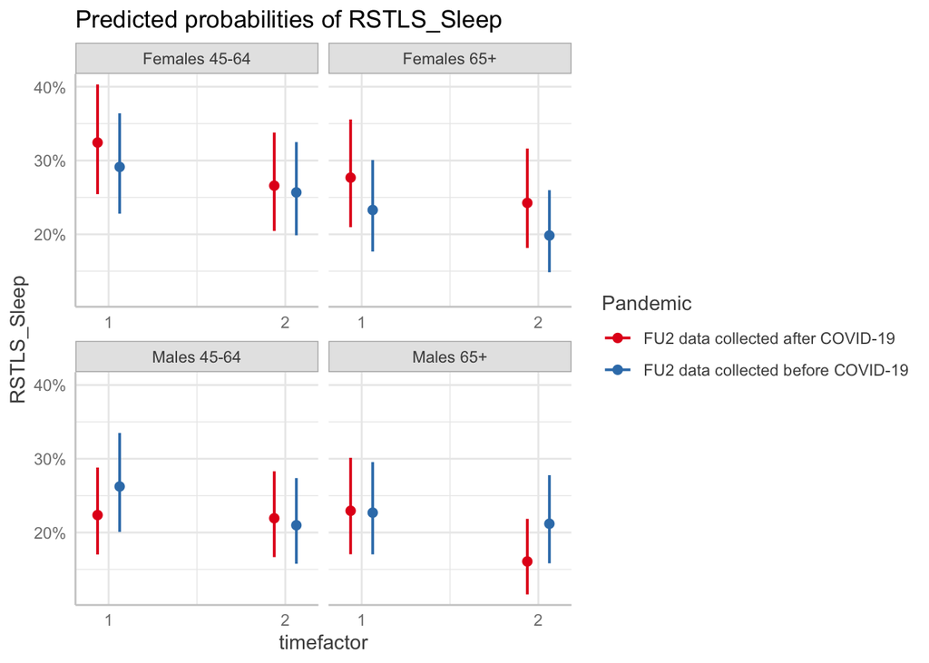

```r
ggpredict(sleep2, c("timefactor","Pandemic","Age_sex")) %>% plot()
```

### 9.2.5) Post-hoc comparisons

Calculating between-cohort changes from FU1 to FU2 for males 65+

```r
####### Males 65+ ###########

#mean difference
mean.diff.Males.Old.1c<-((subset(sleep.test2,x==1 & group == "FU2 data collected after COVID-19" & facet == "Males 65+")$predicted -
         subset(sleep.test2,x==2 & group == "FU2 data collected after COVID-19" & facet == "Males 65+")$predicted))

mean.diff.Males.Old.1d<-((subset(sleep.test2,x==1 & group == "FU2 data collected before COVID-19" & facet == "Males 65+")$predicted -
         subset(sleep.test2,x==2 & group == "FU2 data collected before COVID-19" & facet == "Males 65+")$predicted))

mean.Males.Old.change.1<- mean.diff.Males.Old.1c - mean.diff.Males.Old.1d

#standard error
se.change.Males.Old.1 <-(sqrt(((subset(sleep.test2,x==2 & group == "FU2 data collected after COVID-19" & facet == "Males 65+")$standard.error)^2 +
         (subset(sleep.test2,x==2 & group == "FU2 data collected after COVID-19" & facet == "Males 65+")$standard.error^2 +
            (subset(sleep.test2,x==2 & group == "FU2 data collected before COVID-19" & facet == "Males 65+")$standard.error)^2 +
            (subset(sleep.test2,x==2 & group == "FU2 data collected before COVID-19" & facet == "Males 65+")$standard.error)^2 ))/4))

#confidence interval
UL.Males.Old.change.1<-mean.Males.Old.change.1 + se.change.Males.Old.1*1.96
LL.Males.Old.change.1<-mean.Males.Old.change.1 - se.change.Males.Old.1*1.96

#t-score
t.Males.Old.change.1<-mean.Males.Old.change.1/se.change.Males.Old.1

#degrees of freedom
df.Males.Old.1 <- nrow(Tracking.data_long_2[Tracking.data_long_2$Age_sex == "Males 65+" & !is.na(Tracking.data_long_2$RSTLS_Sleep), ])/2 - 2


#p-value
p.change.Males.Old.1 <- pt(t.Males.Old.change.1, df.Males.Old.1)
```

Estimated between-cohort changes from FU1 to FU2 for males 65+

```r
mean.Males.Old.change.1 #Between-cohort changes from FU1 to FU2
```

```
## [1] 0.05364124
```

```r
LL.Males.Old.change.1 #LL 95% CI
```

```
## [1] 0.004257541
```

```r
UL.Males.Old.change.1 #UL 95% CI
```

```
## [1] 0.1030249
```

```r
p.change.Males.Old.1 #p-value
```

```
## [1] 0.9833111
```

Effect size for males 65+

```r
n_males_65_highsleep<-nrow(subset(Tracking.Adjusted_Final, Age_sex == "Males 65+" & Pandemic == "FU2 data collected after COVID-19" & RSTLS_Sleep_0==1))
n_males_65_lowsleep<-nrow(subset(Tracking.Adjusted_Final, Age_sex == "Males 65+" & Pandemic == "FU2 data collected after COVID-19" & RSTLS_Sleep_0==0))
es.SB.males<-(t.Males.Old.change)*(sqrt((n_males_65_highsleep + n_males_65_lowsleep)/(n_males_65_lowsleep*n_males_65_highsleep)))
print(es.SB.males)
```

```
## [1] -0.3240546
```

# 10) Changes in lifestyle behaviours associated with changes in cognition

## 10.1) Change score regressions

All regressions are stratified by age group

### 10.1.1) Changes in physical activity associated with changes in cognition

RVLT Immediate

```r
RVLT_immediate_change_model_PA.1<- lm(RVLT_Immediate_Change~PASE_Change*Age_sex, data=subset(Tracking.Adjusted_Final, Pandemic == "FU2 data collected after COVID-19"))
summary(RVLT_immediate_change_model_PA.1)
```

```
##
## Call:
## lm(formula = RVLT_Immediate_Change ~ PASE_Change * Age_sex, data = subset(Tracking.Adjusted_Final,
##     Pandemic == "FU2 data collected after COVID-19"))
##
## Residuals:
##     Min      1Q  Median      3Q     Max
## -16.159  -2.226   0.112   2.089  17.363
##
## Coefficients:
##                                 Estimate Std. Error t value Pr(>|t|)
## (Intercept)                    -0.356132   0.110262  -3.230  0.00125 **
## PASE_Change                    -0.003148   0.001485  -2.120  0.03404 *
## Age_sexFemales 65+              0.497397   0.185436   2.682  0.00734 **
## Age_sexMales 45-64             -0.176578   0.143859  -1.227  0.21972
## Age_sexMales 65+                0.461631   0.189862   2.431  0.01508 *
## PASE_Change:Age_sexFemales 65+  0.008304   0.003232   2.569  0.01022 *
## PASE_Change:Age_sexMales 45-64  0.002650   0.001838   1.442  0.14931
## PASE_Change:Age_sexMales 65+    0.002170   0.002862   0.758  0.44827
## ---
## Signif. codes:  0 '***' 0.001 '**' 0.01 '*' 0.05 '.' 0.1 ' ' 1
##
## Residual standard error: 3.944 on 4709 degrees of freedom
##   (464 observations deleted due to missingness)
## Multiple R-squared:  0.00745,    Adjusted R-squared:  0.005975
## F-statistic:  5.05 on 7 and 4709 DF,  p-value: 1.011e-05
```

```r
anova(RVLT_immediate_change_model_PA.1)
```

```
## Analysis of Variance Table
##
## Response: RVLT_Immediate_Change
##                       Df Sum Sq Mean Sq F value    Pr(>F)
## PASE_Change            1     19  18.719  1.2032   0.27274
## Age_sex                3    424 141.389  9.0881 5.375e-06 ***
## PASE_Change:Age_sex    3    107  35.679  2.2934   0.07596 .
## Residuals           4709  73261  15.558
## ---
## Signif. codes:  0 '***' 0.001 '**' 0.01 '*' 0.05 '.' 0.1 ' ' 1
```

RVLT Delayed

```r
RVLT_delayed_change_model_PA.1<- lm(RVLT_Delayed_Change~PASE_Change*Age_sex, data=subset(Tracking.Adjusted_Final, Pandemic == "FU2 data collected after COVID-19"))
summary(RVLT_delayed_change_model_PA.1)
```

```
##
## Call:
## lm(formula = RVLT_Delayed_Change ~ PASE_Change * Age_sex, data = subset(Tracking.Adjusted_Final,
##     Pandemic == "FU2 data collected after COVID-19"))
##
## Residuals:
##      Min       1Q   Median       3Q      Max
## -16.1189  -2.3411   0.3352   2.1355  18.1030
##
## Coefficients:
##                                  Estimate Std. Error t value Pr(>|t|)
## (Intercept)                    -0.7933943  0.1060327  -7.483 8.68e-14 ***
## PASE_Change                    -0.0007697  0.0014240  -0.541    0.589
## Age_sexFemales 65+              0.7280422  0.1802801   4.038 5.47e-05 ***
## Age_sexMales 45-64             -0.0518835  0.1386150  -0.374    0.708
## Age_sexMales 65+                0.7595811  0.1840982   4.126 3.76e-05 ***
## PASE_Change:Age_sexFemales 65+  0.0018003  0.0031259   0.576    0.565
## PASE_Change:Age_sexMales 45-64  0.0017425  0.0017745   0.982    0.326
## PASE_Change:Age_sexMales 65+    0.0014945  0.0027695   0.540    0.589
## ---
## Signif. codes:  0 '***' 0.001 '**' 0.01 '*' 0.05 '.' 0.1 ' ' 1
##
## Residual standard error: 3.78 on 4613 degrees of freedom
##   (560 observations deleted due to missingness)
## Multiple R-squared:  0.009426,   Adjusted R-squared:  0.007923
## F-statistic: 6.271 on 7 and 4613 DF,  p-value: 2.429e-07
```

```r
anova(RVLT_delayed_change_model_PA.1)
```

```
## Analysis of Variance Table
##
## Response: RVLT_Delayed_Change
##                       Df Sum Sq Mean Sq F value    Pr(>F)
## PASE_Change            1      5   5.288  0.3700     0.543
## Age_sex                3    607 202.428 14.1641 3.461e-09 ***
## PASE_Change:Age_sex    3     15   4.927  0.3448     0.793
## Residuals           4613  65927  14.292
## ---
## Signif. codes:  0 '***' 0.001 '**' 0.01 '*' 0.05 '.' 0.1 ' ' 1
```

MAT

```r
MAT_change_model_PA.1<- lm(MAT_Change~PASE_Change*Age_sex, data=subset(Tracking.Adjusted_Final, Pandemic == "FU2 data collected after COVID-19"))
summary(MAT_change_model_PA.1)
```

```
##
## Call:
## lm(formula = MAT_Change ~ PASE_Change * Age_sex, data = subset(Tracking.Adjusted_Final,
##     Pandemic == "FU2 data collected after COVID-19"))
##
## Residuals:
##      Min       1Q   Median       3Q      Max
## -12.9027  -2.6255  -0.5734   1.4485  19.5248
##
## Coefficients:
##                                 Estimate Std. Error t value Pr(>|t|)
## (Intercept)                     3.285540   0.123694  26.562  < 2e-16 ***
## PASE_Change                     0.001499   0.001668   0.898 0.369042
## Age_sexFemales 65+             -0.821748   0.216636  -3.793 0.000151 ***
## Age_sexMales 45-64             -3.317181   0.161992 -20.477  < 2e-16 ***
## Age_sexMales 65+               -2.929784   0.225747 -12.978  < 2e-16 ***
## PASE_Change:Age_sexFemales 65+ -0.003358   0.003725  -0.901 0.367477
## PASE_Change:Age_sexMales 45-64 -0.001689   0.002081  -0.812 0.416959
## PASE_Change:Age_sexMales 65+   -0.002728   0.003386  -0.806 0.420544
## ---
## Signif. codes:  0 '***' 0.001 '**' 0.01 '*' 0.05 '.' 0.1 ' ' 1
##
## Residual standard error: 4.226 on 4077 degrees of freedom
##   (1096 observations deleted due to missingness)
## Multiple R-squared:  0.1133, Adjusted R-squared:  0.1118
## F-statistic: 74.45 on 7 and 4077 DF,  p-value: < 2.2e-16
```

```r
anova(MAT_change_model_PA.1)
```

```
## Analysis of Variance Table
##
## Response: MAT_Change
##                       Df Sum Sq Mean Sq  F value Pr(>F)
## PASE_Change            1      1    0.93   0.0519 0.8198
## Age_sex                3   9282 3094.14 173.2639 <2e-16 ***
## PASE_Change:Age_sex    3     23    7.78   0.4356 0.7275
## Residuals           4077  72807   17.86
## ---
## Signif. codes:  0 '***' 0.001 '**' 0.01 '*' 0.05 '.' 0.1 ' ' 1
```

Animal Fluency

```r
Animals_change_model_PA.1<- lm(Animal_Change~PASE_Change*Age_sex, data=subset(Tracking.Adjusted_Final, Pandemic == "FU2 data collected after COVID-19"))
summary(Animals_change_model_PA.1)
```

```
##
## Call:
## lm(formula = Animal_Change ~ PASE_Change * Age_sex, data = subset(Tracking.Adjusted_Final,
##     Pandemic == "FU2 data collected after COVID-19"))
##
## Residuals:
##     Min      1Q  Median      3Q     Max
## -13.309  -1.827  -0.030   1.770  13.839
##
## Coefficients:
##                                  Estimate Std. Error t value Pr(>|t|)
## (Intercept)                    -2.946e-01  7.819e-02  -3.768 0.000166 ***
## PASE_Change                     7.277e-04  1.054e-03   0.691 0.489847
## Age_sexFemales 65+              4.086e-01  1.310e-01   3.120 0.001821 **
## Age_sexMales 45-64              2.139e-01  1.020e-01   2.096 0.036121 *
## Age_sexMales 65+                5.920e-01  1.339e-01   4.422    1e-05 ***
## PASE_Change:Age_sexFemales 65+  2.628e-03  2.274e-03   1.155 0.247974
## PASE_Change:Age_sexMales 45-64 -8.538e-05  1.307e-03  -0.065 0.947904
## PASE_Change:Age_sexMales 65+   -2.112e-03  2.006e-03  -1.053 0.292435
## ---
## Signif. codes:  0 '***' 0.001 '**' 0.01 '*' 0.05 '.' 0.1 ' ' 1
##
## Residual standard error: 2.806 on 4752 degrees of freedom
##   (421 observations deleted due to missingness)
## Multiple R-squared:  0.005793,   Adjusted R-squared:  0.004328
## F-statistic: 3.955 on 7 and 4752 DF,  p-value: 0.0002574
```

```r
anova(Animals_change_model_PA.1)
```

```
## Analysis of Variance Table
##
## Response: Animal_Change
##                       Df Sum Sq Mean Sq F value    Pr(>F)
## PASE_Change            1     11  10.754  1.3658    0.2426
## Age_sex                3    182  60.617  7.6982 3.959e-05 ***
## PASE_Change:Age_sex    3     25   8.472  1.0760    0.3579
## Residuals           4752  37418   7.874
## ---
## Signif. codes:  0 '***' 0.001 '**' 0.01 '*' 0.05 '.' 0.1 ' ' 1
```

### 10.1.2) Changes in sedentary behaviour associated with changes in cognition

RVLT Immediate

```r
RVLT_immediate_change_model_SB.1<- lm(RVLT_Immediate_Change~factor(SB_binary_change)*Age_sex, data=subset(Tracking.Adjusted_Final, Pandemic == "FU2 data collected after COVID-19"))
summary(RVLT_immediate_change_model_SB.1)
```

```
##
## Call:
## lm(formula = RVLT_Immediate_Change ~ factor(SB_binary_change) *
##     Age_sex, data = subset(Tracking.Adjusted_Final, Pandemic ==
##     "FU2 data collected after COVID-19"))
##
## Residuals:
##      Min       1Q   Median       3Q      Max
## -16.5090  -2.2730   0.1043   2.0898  17.2837
##
## Coefficients:
##                                              Estimate Std. Error t value
## (Intercept)                                  -0.57562    0.28985  -1.986
## factor(SB_binary_change)0                     0.11760    0.31928   0.368
## factor(SB_binary_change)1                     0.37847    0.36329   1.042
## Age_sexFemales 65+                            0.30080    0.47602   0.632
## Age_sexMales 45-64                           -0.38827    0.38501  -1.008
## Age_sexMales 65+                              1.00980    0.48169   2.096
## factor(SB_binary_change)0:Age_sexFemales 65+  0.35213    0.52667   0.669
## factor(SB_binary_change)1:Age_sexFemales 65+  0.44529    0.60453   0.737
## factor(SB_binary_change)0:Age_sexMales 45-64  0.39812    0.42262   0.942
## factor(SB_binary_change)1:Age_sexMales 45-64 -0.02818    0.48319  -0.058
## factor(SB_binary_change)0:Age_sexMales 65+   -0.38357    0.53207  -0.721
## factor(SB_binary_change)1:Age_sexMales 65+   -1.03748    0.60814  -1.706
##                                              Pr(>|t|)
## (Intercept)                                    0.0471 *
## factor(SB_binary_change)0                      0.7126
## factor(SB_binary_change)1                      0.2976
## Age_sexFemales 65+                             0.5275
## Age_sexMales 45-64                             0.3133
## Age_sexMales 65+                               0.0361 *
## factor(SB_binary_change)0:Age_sexFemales 65+   0.5038
## factor(SB_binary_change)1:Age_sexFemales 65+   0.4614
## factor(SB_binary_change)0:Age_sexMales 45-64   0.3462
## factor(SB_binary_change)1:Age_sexMales 45-64   0.9535
## factor(SB_binary_change)0:Age_sexMales 65+     0.4710
## factor(SB_binary_change)1:Age_sexMales 65+     0.0881 .
## ---
## Signif. codes:  0 '***' 0.001 '**' 0.01 '*' 0.05 '.' 0.1 ' ' 1
##
## Residual standard error: 3.942 on 4772 degrees of freedom
##   (397 observations deleted due to missingness)
## Multiple R-squared:  0.008198,   Adjusted R-squared:  0.005911
## F-statistic: 3.586 on 11 and 4772 DF,  p-value: 4.679e-05
```

```r
anova(RVLT_immediate_change_model_SB.1)
```

```
## Analysis of Variance Table
##
## Response: RVLT_Immediate_Change
##                                    Df Sum Sq Mean Sq F value    Pr(>F)
## factor(SB_binary_change)            2     35  17.703  1.1390    0.3202
## Age_sex                             3    463 154.213  9.9224 1.613e-06 ***
## factor(SB_binary_change):Age_sex    6    115  19.160  1.2328    0.2859
## Residuals                        4772  74166  15.542
## ---
## Signif. codes:  0 '***' 0.001 '**' 0.01 '*' 0.05 '.' 0.1 ' ' 1
```

RVLT Delayed

```r
RVLT_delayed_change_model_SB.1<- lm(RVLT_Delayed_Change~factor(SB_binary_change)*Age_sex, data=subset(Tracking.Adjusted_Final, Pandemic == "FU2 data collected after COVID-19"))
summary(RVLT_delayed_change_model_SB.1)
```

```
##
## Call:
## lm(formula = RVLT_Delayed_Change ~ factor(SB_binary_change) *
##     Age_sex, data = subset(Tracking.Adjusted_Final, Pandemic ==
##     "FU2 data collected after COVID-19"))
##
## Residuals:
##      Min       1Q   Median       3Q      Max
## -16.1056  -2.3543   0.3417   2.1502  18.7155
##
## Coefficients:
##                                              Estimate Std. Error t value
## (Intercept)                                   -1.0524     0.2765  -3.806
## factor(SB_binary_change)0                      0.2576     0.3050   0.845
## factor(SB_binary_change)1                      0.3579     0.3473   1.030
## Age_sexFemales 65+                             0.3257     0.4618   0.705
## Age_sexMales 45-64                            -0.1012     0.3701  -0.273
## Age_sexMales 65+                               1.0627     0.4662   2.280
## factor(SB_binary_change)0:Age_sexFemales 65+   0.4628     0.5109   0.906
## factor(SB_binary_change)1:Age_sexFemales 65+   0.6330     0.5862   1.080
## factor(SB_binary_change)0:Age_sexMales 45-64   0.1707     0.4063   0.420
## factor(SB_binary_change)1:Age_sexMales 45-64  -0.1464     0.4652  -0.315
## factor(SB_binary_change)0:Age_sexMales 65+    -0.1234     0.5149  -0.240
## factor(SB_binary_change)1:Age_sexMales 65+    -0.7616     0.5892  -1.293
##                                              Pr(>|t|)
## (Intercept)                                  0.000143 ***
## factor(SB_binary_change)0                    0.398407
## factor(SB_binary_change)1                    0.302912
## Age_sexFemales 65+                           0.480645
## Age_sexMales 45-64                           0.784537
## Age_sexMales 65+                             0.022664 *
## factor(SB_binary_change)0:Age_sexFemales 65+ 0.365012
## factor(SB_binary_change)1:Age_sexFemales 65+ 0.280263
## factor(SB_binary_change)0:Age_sexMales 45-64 0.674342
## factor(SB_binary_change)1:Age_sexMales 45-64 0.753020
## factor(SB_binary_change)0:Age_sexMales 65+   0.810683
## factor(SB_binary_change)1:Age_sexMales 65+   0.196201
## ---
## Signif. codes:  0 '***' 0.001 '**' 0.01 '*' 0.05 '.' 0.1 ' ' 1
##
## Residual standard error: 3.771 on 4675 degrees of freedom
##   (494 observations deleted due to missingness)
## Multiple R-squared:  0.01176,    Adjusted R-squared:  0.009433
## F-statistic: 5.057 on 11 and 4675 DF,  p-value: 6.688e-08
```

```r
anova(RVLT_delayed_change_model_SB.1)
```

```
## Analysis of Variance Table
##
## Response: RVLT_Delayed_Change
##                                    Df Sum Sq Mean Sq F value    Pr(>F)
## factor(SB_binary_change)            2     68  33.956  2.3873   0.09199 .
## Age_sex                             3    640 213.460 15.0072 1.015e-09 ***
## factor(SB_binary_change):Age_sex    6     83  13.818  0.9714   0.44279
## Residuals                        4675  66497  14.224
## ---
## Signif. codes:  0 '***' 0.001 '**' 0.01 '*' 0.05 '.' 0.1 ' ' 1
```

MAT

```r
MAT_change_model_SB.1<- lm(MAT_Change~factor(SB_binary_change)*Age_sex, data=subset(Tracking.Adjusted_Final, Pandemic == "FU2 data collected after COVID-19"))
summary(MAT_change_model_SB.1)
```

```
##
## Call:
## lm(formula = MAT_Change ~ factor(SB_binary_change) * Age_sex,
##     data = subset(Tracking.Adjusted_Final, Pandemic == "FU2 data collected after COVID-19"))
##
## Residuals:
##      Min       1Q   Median       3Q      Max
## -12.9893  -2.5702  -0.5797   1.4388  19.6123
##
## Coefficients:
##                                              Estimate Std. Error t value
## (Intercept)                                    4.2327     0.3263  12.973
## factor(SB_binary_change)0                     -1.0808     0.3592  -3.009
## factor(SB_binary_change)1                     -1.0452     0.4081  -2.561
## Age_sexFemales 65+                            -2.0896     0.5554  -3.762
## Age_sexMales 45-64                            -4.3064     0.4349  -9.902
## Age_sexMales 65+                              -3.6229     0.5733  -6.319
## factor(SB_binary_change)0:Age_sexFemales 65+   1.3895     0.6140   2.263
## factor(SB_binary_change)1:Age_sexFemales 65+   1.4172     0.7087   2.000
## factor(SB_binary_change)0:Age_sexMales 45-64   1.1300     0.4771   2.368
## factor(SB_binary_change)1:Age_sexMales 45-64   1.0153     0.5445   1.865
## factor(SB_binary_change)0:Age_sexMales 65+     0.8888     0.6323   1.406
## factor(SB_binary_change)1:Age_sexMales 65+     0.3970     0.7228   0.549
##                                              Pr(>|t|)
## (Intercept)                                   < 2e-16 ***
## factor(SB_binary_change)0                    0.002635 **
## factor(SB_binary_change)1                    0.010460 *
## Age_sexFemales 65+                           0.000171 ***
## Age_sexMales 45-64                            < 2e-16 ***
## Age_sexMales 65+                             2.91e-10 ***
## factor(SB_binary_change)0:Age_sexFemales 65+ 0.023674 *
## factor(SB_binary_change)1:Age_sexFemales 65+ 0.045588 *
## factor(SB_binary_change)0:Age_sexMales 45-64 0.017915 *
## factor(SB_binary_change)1:Age_sexMales 45-64 0.062295 .
## factor(SB_binary_change)0:Age_sexMales 65+   0.159909
## factor(SB_binary_change)1:Age_sexMales 65+   0.582849
## ---
## Signif. codes:  0 '***' 0.001 '**' 0.01 '*' 0.05 '.' 0.1 ' ' 1
##
## Residual standard error: 4.216 on 4131 degrees of freedom
##   (1038 observations deleted due to missingness)
## Multiple R-squared:  0.1156, Adjusted R-squared:  0.1133
## F-statistic:  49.1 on 11 and 4131 DF,  p-value: < 2.2e-16
```

```r
anova(MAT_change_model_SB.1)
```

```
## Analysis of Variance Table
##
## Response: MAT_Change
##                                    Df Sum Sq Mean Sq  F value Pr(>F)
## factor(SB_binary_change)            2     60   30.01   1.6880 0.1850
## Age_sex                             3   9388 3129.21 176.0135 <2e-16 ***
## factor(SB_binary_change):Age_sex    6    154   25.69   1.4453 0.1932
## Residuals                        4131  73442   17.78
## ---
## Signif. codes:  0 '***' 0.001 '**' 0.01 '*' 0.05 '.' 0.1 ' ' 1
```

Animals Fluency

```r
Animals_change_model_SB.1<- lm(Animal_Change~factor(SB_binary_change)*Age_sex, data=subset(Tracking.Adjusted_Final, Pandemic == "FU2 data collected after COVID-19"))
summary(Animals_change_model_SB.1)
```

```
##
## Call:
## lm(formula = Animal_Change ~ factor(SB_binary_change) * Age_sex,
##     data = subset(Tracking.Adjusted_Final, Pandemic == "FU2 data collected after COVID-19"))
##
## Residuals:
##      Min       1Q   Median       3Q      Max
## -13.1820  -1.7873  -0.0287   1.7770  13.8214
##
## Coefficients:
##                                              Estimate Std. Error t value
## (Intercept)                                  -0.13800    0.20451  -0.675
## factor(SB_binary_change)0                    -0.14511    0.22548  -0.644
## factor(SB_binary_change)1                    -0.16958    0.25694  -0.660
## Age_sexFemales 65+                            0.53181    0.33661   1.580
## Age_sexMales 45-64                           -0.04602    0.27336  -0.168
## Age_sexMales 65+                              0.22246    0.33958   0.655
## factor(SB_binary_change)0:Age_sexFemales 65+ -0.23004    0.37234  -0.618
## factor(SB_binary_change)1:Age_sexFemales 65+  0.15766    0.42713   0.369
## factor(SB_binary_change)0:Age_sexMales 45-64  0.32767    0.29998   1.092
## factor(SB_binary_change)1:Age_sexMales 45-64  0.17753    0.34339   0.517
## factor(SB_binary_change)0:Age_sexMales 65+    0.41334    0.37507   1.102
## factor(SB_binary_change)1:Age_sexMales 65+    0.28087    0.42947   0.654
##                                              Pr(>|t|)
## (Intercept)                                     0.500
## factor(SB_binary_change)0                       0.520
## factor(SB_binary_change)1                       0.509
## Age_sexFemales 65+                              0.114
## Age_sexMales 45-64                              0.866
## Age_sexMales 65+                                0.512
## factor(SB_binary_change)0:Age_sexFemales 65+    0.537
## factor(SB_binary_change)1:Age_sexFemales 65+    0.712
## factor(SB_binary_change)0:Age_sexMales 45-64    0.275
## factor(SB_binary_change)1:Age_sexMales 45-64    0.605
## factor(SB_binary_change)0:Age_sexMales 65+      0.271
## factor(SB_binary_change)1:Age_sexMales 65+      0.513
##
## Residual standard error: 2.804 on 4815 degrees of freedom
##   (354 observations deleted due to missingness)
## Multiple R-squared:  0.006036,   Adjusted R-squared:  0.003766
## F-statistic: 2.658 on 11 and 4815 DF,  p-value: 0.002128
```

```r
anova(Animals_change_model_SB.1)
```

```
## Analysis of Variance Table
##
## Response: Animal_Change
##                                    Df Sum Sq Mean Sq F value   Pr(>F)
## factor(SB_binary_change)            2      2   0.766  0.0974   0.9072
## Age_sex                             3    180  60.103  7.6436 4.28e-05 ***
## factor(SB_binary_change):Age_sex    6     48   8.015  1.0193   0.4105
## Residuals                        4815  37861   7.863
## ---
## Signif. codes:  0 '***' 0.001 '**' 0.01 '*' 0.05 '.' 0.1 ' ' 1
```

### 10.1.3) Changes in sleep associated with changes in cognition

RVLT Immediate

```r
RVLT_immediate_change_model_sleep.1<- lm(RVLT_Immediate_Change~factor(sleep_change)*Age_sex, data=subset(Tracking.Adjusted_Final, Pandemic == "FU2 data collected after COVID-19"))
summary(RVLT_immediate_change_model_sleep.1)
```

```
##
## Call:
## lm(formula = RVLT_Immediate_Change ~ factor(sleep_change) * Age_sex,
##     data = subset(Tracking.Adjusted_Final, Pandemic == "FU2 data collected after COVID-19"))
##
## Residuals:
##      Min       1Q   Median       3Q      Max
## -16.0917  -2.2242   0.0395   2.2887  17.4074
##
## Coefficients:
##                                          Estimate Std. Error t value Pr(>|t|)
## (Intercept)                              -0.82311    0.22984  -3.581 0.000345
## factor(sleep_change)0                     0.51892    0.26628   1.949 0.051384
## factor(sleep_change)1                     0.51602    0.34961   1.476 0.140019
## Age_sexFemales 65+                        1.20741    0.39326   3.070 0.002151
## Age_sexMales 45-64                       -0.05429    0.32702  -0.166 0.868152
## Age_sexMales 65+                          1.03410    0.40132   2.577 0.010004
## factor(sleep_change)0:Age_sexFemales 65+ -0.77157    0.45342  -1.702 0.088885
## factor(sleep_change)1:Age_sexFemales 65+ -0.35375    0.58816  -0.601 0.547569
## factor(sleep_change)0:Age_sexMales 45-64 -0.05441    0.36942  -0.147 0.882915
## factor(sleep_change)1:Age_sexMales 45-64 -0.55431    0.48362  -1.146 0.251780
## factor(sleep_change)0:Age_sexMales 65+   -0.68540    0.45750  -1.498 0.134167
## factor(sleep_change)1:Age_sexMales 65+   -0.34608    0.63590  -0.544 0.586307
##
## (Intercept)                              ***
## factor(sleep_change)0                    .
## factor(sleep_change)1
## Age_sexFemales 65+                       **
## Age_sexMales 45-64
## Age_sexMales 65+                         *
## factor(sleep_change)0:Age_sexFemales 65+ .
## factor(sleep_change)1:Age_sexFemales 65+
## factor(sleep_change)0:Age_sexMales 45-64
## factor(sleep_change)1:Age_sexMales 45-64
## factor(sleep_change)0:Age_sexMales 65+
## factor(sleep_change)1:Age_sexMales 65+
## ---
## Signif. codes:  0 '***' 0.001 '**' 0.01 '*' 0.05 '.' 0.1 ' ' 1
##
## Residual standard error: 3.934 on 4762 degrees of freedom
##   (407 observations deleted due to missingness)
## Multiple R-squared:  0.009178,   Adjusted R-squared:  0.006889
## F-statistic:  4.01 on 11 and 4762 DF,  p-value: 7.415e-06
```

```r
anova(RVLT_immediate_change_model_sleep.1)
```

```
## Analysis of Variance Table
##
## Response: RVLT_Immediate_Change
##                                Df Sum Sq Mean Sq F value    Pr(>F)
## factor(sleep_change)            2     37  18.544  1.1981    0.3018
## Age_sex                         3    510 169.851 10.9741 3.528e-07 ***
## factor(sleep_change):Age_sex    6    136  22.683  1.4655    0.1858
## Residuals                    4762  73704  15.478
## ---
## Signif. codes:  0 '***' 0.001 '**' 0.01 '*' 0.05 '.' 0.1 ' ' 1
```

RVLT Delayed

```r
RVLT_delayed_change_model_sleep.1<- lm(RVLT_Delayed_Change~factor(sleep_change)*Age_sex, data=subset(Tracking.Adjusted_Final, Pandemic == "FU2 data collected after COVID-19"))
summary(RVLT_delayed_change_model_sleep.1)
```

```
##
## Call:
## lm(formula = RVLT_Delayed_Change ~ factor(sleep_change) * Age_sex,
##     data = subset(Tracking.Adjusted_Final, Pandemic == "FU2 data collected after COVID-19"))
##
## Residuals:
##      Min       1Q   Median       3Q      Max
## -15.9693  -2.3816   0.2879   2.1693  17.9079
##
## Coefficients:
##                                          Estimate Std. Error t value Pr(>|t|)
## (Intercept)                              -1.23613    0.22142  -5.583  2.5e-08
## factor(sleep_change)0                     0.52920    0.25639   2.064 0.039066
## factor(sleep_change)1                     0.62288    0.33669   1.850 0.064374
## Age_sexFemales 65+                        0.71179    0.38620   1.843 0.065384
## Age_sexMales 45-64                        0.61374    0.31563   1.944 0.051896
## Age_sexMales 65+                          1.50893    0.39386   3.831 0.000129
## factor(sleep_change)0:Age_sexFemales 65+  0.07605    0.44397   0.171 0.863996
## factor(sleep_change)1:Age_sexFemales 65+  0.11452    0.57204   0.200 0.841340
## factor(sleep_change)0:Age_sexMales 45-64 -0.72216    0.35640  -2.026 0.042795
## factor(sleep_change)1:Age_sexMales 45-64 -1.15295    0.46714  -2.468 0.013619
## factor(sleep_change)0:Age_sexMales 65+   -0.92790    0.44771  -2.073 0.038269
## factor(sleep_change)1:Age_sexMales 65+   -0.46780    0.61580  -0.760 0.447497
##
## (Intercept)                              ***
## factor(sleep_change)0                    *
## factor(sleep_change)1                    .
## Age_sexFemales 65+                       .
## Age_sexMales 45-64                       .
## Age_sexMales 65+                         ***
## factor(sleep_change)0:Age_sexFemales 65+
## factor(sleep_change)1:Age_sexFemales 65+
## factor(sleep_change)0:Age_sexMales 45-64 *
## factor(sleep_change)1:Age_sexMales 45-64 *
## factor(sleep_change)0:Age_sexMales 65+   *
## factor(sleep_change)1:Age_sexMales 65+
## ---
## Signif. codes:  0 '***' 0.001 '**' 0.01 '*' 0.05 '.' 0.1 ' ' 1
##
## Residual standard error: 3.771 on 4665 degrees of freedom
##   (504 observations deleted due to missingness)
## Multiple R-squared:  0.01289,    Adjusted R-squared:  0.01057
## F-statistic: 5.539 on 11 and 4665 DF,  p-value: 7.189e-09
```

```r
anova(RVLT_delayed_change_model_sleep.1)
```

```
## Analysis of Variance Table
##
## Response: RVLT_Delayed_Change
##                                Df Sum Sq Mean Sq F value    Pr(>F)
## factor(sleep_change)            2     12   5.917  0.4162   0.65959
## Age_sex                         3    679 226.273 15.9149 2.711e-10 ***
## factor(sleep_change):Age_sex    6    176  29.273  2.0589   0.05475 .
## Residuals                    4665  66326  14.218
## ---
## Signif. codes:  0 '***' 0.001 '**' 0.01 '*' 0.05 '.' 0.1 ' ' 1
```

MAT

```r
MAT_change_model_sleep.1<- lm(MAT_Change~factor(sleep_change)*Age_sex, data=subset(Tracking.Adjusted_Final, Pandemic == "FU2 data collected after COVID-19"))
summary(MAT_change_model_sleep.1)
```

```
##
## Call:
## lm(formula = MAT_Change ~ factor(sleep_change) * Age_sex, data = subset(Tracking.Adjusted_Final,
##     Pandemic == "FU2 data collected after COVID-19"))
##
## Residuals:
##      Min       1Q   Median       3Q      Max
## -13.0040  -2.6018  -0.5795   1.4444  19.3618
##
## Coefficients:
##                                          Estimate Std. Error t value Pr(>|t|)
## (Intercept)                               3.23965    0.25785  12.564  < 2e-16
## factor(sleep_change)0                     0.16277    0.29913   0.544   0.5864
## factor(sleep_change)1                    -0.13171    0.39167  -0.336   0.7367
## Age_sexFemales 65+                       -0.79043    0.46499  -1.700   0.0892
## Age_sexMales 45-64                       -3.40499    0.36927  -9.221  < 2e-16
## Age_sexMales 65+                         -2.90551    0.47646  -6.098 1.17e-09
## factor(sleep_change)0:Age_sexFemales 65+ -0.12230    0.53409  -0.229   0.8189
## factor(sleep_change)1:Age_sexFemales 65+ -0.12994    0.69377  -0.187   0.8514
## factor(sleep_change)0:Age_sexMales 45-64 -0.02752    0.41720  -0.066   0.9474
## factor(sleep_change)1:Age_sexMales 45-64  0.29845    0.54603   0.547   0.5847
## factor(sleep_change)0:Age_sexMales 65+   -0.17041    0.54242  -0.314   0.7534
## factor(sleep_change)1:Age_sexMales 65+    0.23009    0.77250   0.298   0.7658
##
## (Intercept)                              ***
## factor(sleep_change)0
## factor(sleep_change)1
## Age_sexFemales 65+                       .
## Age_sexMales 45-64                       ***
## Age_sexMales 65+                         ***
## factor(sleep_change)0:Age_sexFemales 65+
## factor(sleep_change)1:Age_sexFemales 65+
## factor(sleep_change)0:Age_sexMales 45-64
## factor(sleep_change)1:Age_sexMales 45-64
## factor(sleep_change)0:Age_sexMales 65+
## factor(sleep_change)1:Age_sexMales 65+
## ---
## Signif. codes:  0 '***' 0.001 '**' 0.01 '*' 0.05 '.' 0.1 ' ' 1
##
## Residual standard error: 4.221 on 4124 degrees of freedom
##   (1045 observations deleted due to missingness)
## Multiple R-squared:  0.1143, Adjusted R-squared:  0.1119
## F-statistic: 48.38 on 11 and 4124 DF,  p-value: < 2.2e-16
```

```r
anova(MAT_change_model_sleep.1)
```

```
## Analysis of Variance Table
##
## Response: MAT_Change
##                                Df Sum Sq Mean Sq  F value Pr(>F)
## factor(sleep_change)            2     28   13.98   0.7845 0.4564
## Age_sex                         3   9438 3145.89 176.5552 <2e-16 ***
## factor(sleep_change):Age_sex    6     17    2.88   0.1615 0.9867
## Residuals                    4124  73482   17.82
## ---
## Signif. codes:  0 '***' 0.001 '**' 0.01 '*' 0.05 '.' 0.1 ' ' 1
```

Animal Fluency

```r
Animals_change_model_sleep.1<- lm(Animal_Change~factor(sleep_change)*Age_sex, data=subset(Tracking.Adjusted_Final, Pandemic == "FU2 data collected after COVID-19"))
summary(Animals_change_model_sleep.1)
```

```
##
## Call:
## lm(formula = Animal_Change ~ factor(sleep_change) * Age_sex,
##     data = subset(Tracking.Adjusted_Final, Pandemic == "FU2 data collected after COVID-19"))
##
## Residuals:
##      Min       1Q   Median       3Q      Max
## -13.2058  -1.7789  -0.0308   1.7783  13.8801
##
## Coefficients:
##                                           Estimate Std. Error t value Pr(>|t|)
## (Intercept)                              -0.380939   0.164039  -2.322   0.0203
## factor(sleep_change)0                     0.160587   0.189799   0.846   0.3975
## factor(sleep_change)1                     0.062735   0.249529   0.251   0.8015
## Age_sexFemales 65+                        0.711412   0.281288   2.529   0.0115
## Age_sexMales 45-64                        0.164435   0.232385   0.708   0.4792
## Age_sexMales 65+                          0.679535   0.284449   2.389   0.0169
## factor(sleep_change)0:Age_sexFemales 65+ -0.376172   0.323308  -1.164   0.2447
## factor(sleep_change)1:Age_sexFemales 65+ -0.350729   0.418482  -0.838   0.4020
## factor(sleep_change)0:Age_sexMales 45-64 -0.004201   0.262598  -0.016   0.9872
## factor(sleep_change)1:Age_sexMales 45-64  0.287077   0.344325   0.834   0.4045
## factor(sleep_change)0:Age_sexMales 65+   -0.150485   0.324105  -0.464   0.6424
## factor(sleep_change)1:Age_sexMales 65+   -0.246817   0.451520  -0.547   0.5847
##
## (Intercept)                              *
## factor(sleep_change)0
## factor(sleep_change)1
## Age_sexFemales 65+                       *
## Age_sexMales 45-64
## Age_sexMales 65+                         *
## factor(sleep_change)0:Age_sexFemales 65+
## factor(sleep_change)1:Age_sexFemales 65+
## factor(sleep_change)0:Age_sexMales 45-64
## factor(sleep_change)1:Age_sexMales 45-64
## factor(sleep_change)0:Age_sexMales 65+
## factor(sleep_change)1:Age_sexMales 65+
## ---
## Signif. codes:  0 '***' 0.001 '**' 0.01 '*' 0.05 '.' 0.1 ' ' 1
##
## Residual standard error: 2.808 on 4806 degrees of freedom
##   (363 observations deleted due to missingness)
## Multiple R-squared:  0.005585,   Adjusted R-squared:  0.003309
## F-statistic: 2.454 on 11 and 4806 DF,  p-value: 0.00469
```

```r
anova(Animals_change_model_sleep.1)
```

```
## Analysis of Variance Table
##
## Response: Animal_Change
##                                Df Sum Sq Mean Sq F value    Pr(>F)
## factor(sleep_change)            2      4   1.973  0.2502    0.7786
## Age_sex                         3    179  59.607  7.5602 4.824e-05 ***
## factor(sleep_change):Age_sex    6     30   5.008  0.6351    0.7023
## Residuals                    4806  37892   7.884
## ---
## Signif. codes:  0 '***' 0.001 '**' 0.01 '*' 0.05 '.' 0.1 ' ' 1
```